# Análisis Exploratorio de Datos

```python
import pandas as pd, numpy as np, matplotlib.pyplot as plt, seaborn as sns
from scipy.cluster.hierarchy import linkage, leaves_list
from scipy.spatial.distance import squareform

plt.style.use("seaborn-v0_8-whitegrid")
plt.rcParams.update({"figure.figsize": (9, 6), "figure.dpi": 110, "axes.titlesize": 15, "axes.titleweight": "bold", "font.size": 11, "axes.edgecolor": "#BBBBBB"})
pd.set_option("display.max_rows", 250)
pd.set_option("display.width", 160)

df = pd.read_csv("dataset_calidad_aire.csv")
```

```python
# Limpiar columnas que vienen como strings pero son números
df["Año"] = df["Año"].astype(str).str.replace(",", "").astype(int)
columnas_numericas = ["ID Estacion", "Suma", "No. de datos", "Promedio", "Mediana", "Percentil 98", "Máximo", "Mínimo"]
for col in columnas_numericas:
    if col in df.columns:
        df[col] = df[col].astype(str).str.replace(",", "").str.strip()
        df[col] = pd.to_numeric(df[col], errors="coerce")
print("Limpieza completada")
print(df.dtypes)
```

```
Limpieza completada
ID Estacion                               int64
Autoridad Ambiental                         str
Estación                                    str
Latitud                                 float64
Longitud                                float64
Variable                                    str
Unidades                                    str
Tiempo de exposición (horas)              int64
Año                                       int64
Promedio                                float64
Suma                                    float64
No. de datos                              int64
Representatividad Temporal              float64
Excedencias limite actual                 int64
Porcentaje excedencias limite actual    float64
Mediana                                 float64
Percentil 98                            float64
Máximo                                  float64
Fechas/horas del máximo                     str
Mínimo                                  float64
Fechas/horas del mínimo                     str
Días de excedencias                       int64
Código del Departamento                   int64
Nombre del Departamento                     str
Código del Municipio                    float64
Nombre del Municipio                        str
Tipo de Estación                            str
Ubicacion                                   str
dtype: object
```

```python
# Helper para mostrar tablas parecidas a las R
def tabla(d, columnas=None, decimales=2):
    d = d.copy()
    if columnas is not None: d.columns = columnas
    return d.round(decimales).style.hide(axis="index").set_table_styles([{"selector": "th, td", "props": [("border", "1px solid #999999"), ("padding", "4px 10px"), ("text-align", "left")]}])
```

# 1. Preparación y calidad de los datos

```python
df.shape
```

```
(29683, 28)
```

```python
df.info()
```

```
<class 'pandas.DataFrame'>
RangeIndex: 29683 entries, 0 to 29682
Data columns (total 28 columns):
 #   Column                                Non-Null Count  Dtype
---  ------                                --------------  -----
 0   ID Estacion                           29683 non-null  int64
 1   Autoridad Ambiental                   29683 non-null  str
 2   Estación                              29683 non-null  str
 3   Latitud                               29683 non-null  float64
 4   Longitud                              29683 non-null  float64
 5   Variable                              29683 non-null  str
 6   Unidades                              29683 non-null  str
 7   Tiempo de exposición (horas)          29683 non-null  int64
 8   Año                                   29683 non-null  int64
 9   Promedio                              29683 non-null  float64
```

[output cut: 20 more lines]

```python
list(df.columns)
```

```
['ID Estacion',
 'Autoridad Ambiental',
 'Estación',
 'Latitud',
 'Longitud',
 'Variable',
 'Unidades',
 'Tiempo de exposición (horas)',
 'Año',
 'Promedio',
 'Suma',
 'No. de datos',
 'Representatividad Temporal',
 'Excedencias limite actual',
 'Porcentaje excedencias limite actual',
 'Mediana',
 'Percentil 98',
 'Máximo',
 'Fechas/horas del máximo',
 'Mínimo',
 'Fechas/horas del mínimo',
 'Días de excedencias',
 'Código del Departamento',
 'Nombre del Departamento',
 'Código del Municipio',
 'Nombre del Municipio',
 'Tipo de Estación',
 'Ubicacion']
```

```python
df.isna().sum()
```

```
ID Estacion                               0
Autoridad Ambiental                       0
Estación                                  0
Latitud                                   0
Longitud                                  0
Variable                                  0
Unidades                                  0
Tiempo de exposición (horas)              0
Año                                       0
Promedio                                  0
Suma                                      0
No. de datos                              0
Representatividad Temporal              148
Excedencias limite actual                 0
Porcentaje excedencias limite actual      0
Mediana                                   0
Percentil 98                              0
Máximo                                    0
Fechas/horas del máximo                   0
Mínimo                                    0
Fechas/horas del mínimo                   0
Días de excedencias                       0
Código del Departamento                   0
Nombre del Departamento                   0
Código del Municipio                      4
Nombre del Municipio                      0
Tipo de Estación                          2
Ubicacion                                 0
dtype: int64
```

```python
porcentaje_na = df.isna().sum() / len(df) * 100
porcentaje_na
```

```
ID Estacion                             0.000000
Autoridad Ambiental                     0.000000
Estación                                0.000000
Latitud                                 0.000000
Longitud                                0.000000
Variable                                0.000000
Unidades                                0.000000
Tiempo de exposición (horas)            0.000000
Año                                     0.000000
Promedio                                0.000000
Suma                                    0.000000
No. de datos                            0.000000
Representatividad Temporal              0.498602
Excedencias limite actual               0.000000
Porcentaje excedencias limite actual    0.000000
Mediana                                 0.000000
Percentil 98                            0.000000
Máximo                                  0.000000
Fechas/horas del máximo                 0.000000
Mínimo                                  0.000000
Fechas/horas del mínimo                 0.000000
Días de excedencias                     0.000000
Código del Departamento                 0.000000
Nombre del Departamento                 0.000000
Código del Municipio                    0.013476
Nombre del Municipio                    0.000000
Tipo de Estación                        0.006738
Ubicacion                               0.000000
dtype: float64
```

```python
df.duplicated().sum()
```

```
np.int64(13938)
```

```python
df_unicos = df.drop_duplicates()
print("Filas originales:", len(df))
print("Filas únicas:", len(df_unicos))
print("Duplicados:", len(df) - len(df_unicos))
```

```
Filas originales: 29683
Filas únicas: 15745
Duplicados: 13938
```

```python
porcentaje_duplicados = df.duplicated().sum() / len(df) * 100
print("Porcentaje de filas duplicadas:", round(porcentaje_duplicados, 2), "%")
```

```
Porcentaje de filas duplicadas: 46.96 %
```

```python
df = df.drop_duplicates().reset_index(drop=True)
df.shape
```

```
(15745, 28)
```

```python
df.duplicated().sum()
```

```
np.int64(0)
```

## 1.1 Exploración general del dataset

```python
df["Variable"].value_counts().sort_index()
```

```
Variable
CO           719
DViento     1099
HAire         75
HAire10      361
HAire2       693
NO           291
NO2          644
O3           827
P            673
PLiquida     927
PM10        2984
PM2.5       1984
PST          241
RGlobal      600
RUVb          66
SO2         1066
TAire         73
TAire10      334
TAire2       834
VViento     1254
Name: count, dtype: int64
```

```python
df["Variable"].nunique()
```

```
20
```

### 1.1.1 Distribución de registros por estación

```python
df["Estación"].nunique()
```

```
654
```

```python
registros_estacion = df["Estación"].value_counts().rename_axis("Estación").reset_index(name="n")
registros_estacion.head(10)
```

|  | Estación | n |
| --- | --- | --- |
| 0 | C. ALTO RENDIMIENTO | 281 |
| 1 | KENNEDY | 281 |
| 2 | TUNAL | 265 |
| 3 | LAS FERIAS | 256 |
| 4 | GUAYMARAL | 250 |
| 5 | PUENTE ARANDA | 247 |
| 6 | CARVAJAL - SEVILLANA | 245 |
| 7 | SAN CRISTÓBAL | 224 |
| 8 | SUBA | 214 |
| 9 | POLITÉCNICO JIC | 212 |

```python
def barras_h(d, cat, val, titulo, xlab, ylab, subtitulo=None, alto=6, tam=9, dec=0):
    d = d.sort_values(val)
    fig, ax = plt.subplots(figsize=(9, alto))
    ax.barh(d[cat].astype(str), d[val], color="#595959")
    for y, v in zip(d[cat].astype(str), d[val]): ax.text(v * 1.01, y, f"{v:.{dec}f}", va="center", fontsize=tam)
    ax.set_xlim(0, d[val].max() * 1.08)
    ax.set_title(titulo if subtitulo is None else titulo + "\n" + subtitulo, fontweight="bold")
    ax.set_xlabel(xlab); ax.set_ylabel(ylab); ax.grid(axis="y", visible=False)
    plt.tight_layout(); plt.show()
```

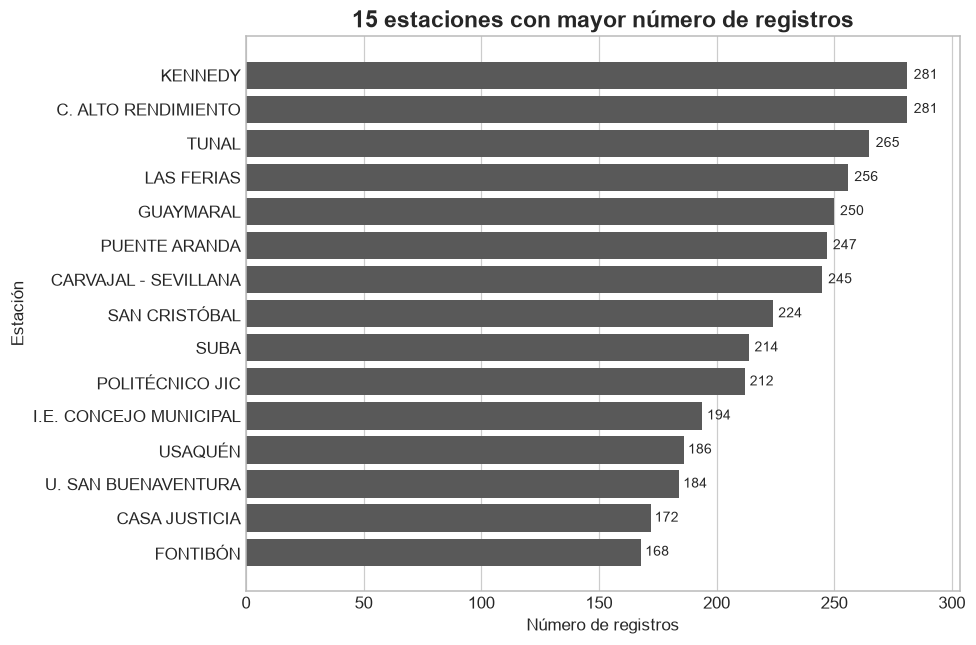

```python
top_estaciones = registros_estacion.nlargest(15, "n")
barras_h(top_estaciones, "Estación", "n", "15 estaciones con mayor número de registros", "Número de registros", "Estación")
```

### 1.1.2 Distribución de registros por variable ambiental

```python
frecuencia_variables = df["Variable"].value_counts().rename_axis("Variable").reset_index(name="n")
frecuencia_variables
```

|  | Variable | n |
| --- | --- | --- |
| 0 | PM10 | 2984 |
| 1 | PM2.5 | 1984 |
| 2 | VViento | 1254 |
| 3 | DViento | 1099 |
| 4 | SO2 | 1066 |
| 5 | PLiquida | 927 |
| 6 | TAire2 | 834 |
| 7 | O3 | 827 |
| 8 | CO | 719 |
| 9 | HAire2 | 693 |
| 10 | P | 673 |
| 11 | NO2 | 644 |
| 12 | RGlobal | 600 |
| 13 | HAire10 | 361 |
| 14 | TAire10 | 334 |
| 15 | NO | 291 |
| 16 | PST | 241 |
| 17 | HAire | 75 |
| 18 | TAire | 73 |
| 19 | RUVb | 66 |

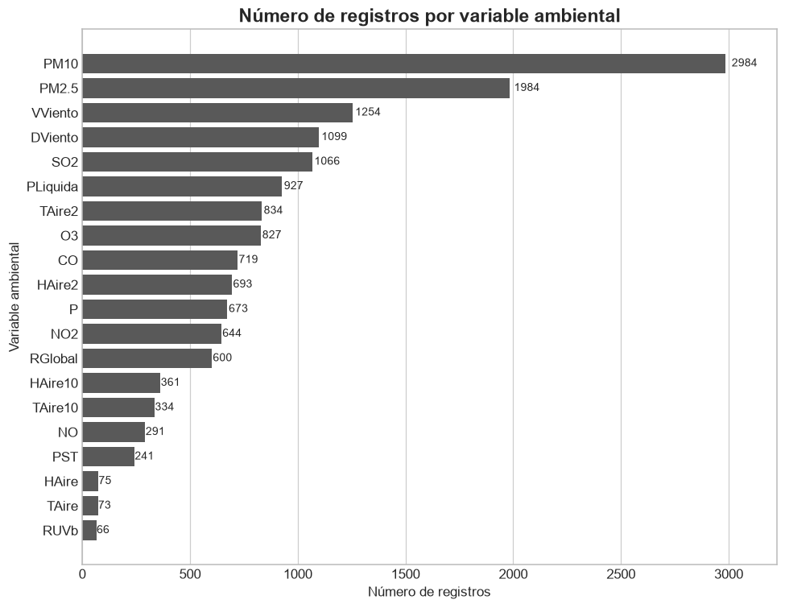

```python
barras_h(frecuencia_variables, "Variable", "n", "Número de registros por variable ambiental", "Número de registros", "Variable ambiental", alto=7)
```

## 1.2 Distribución temporal de los registros

```python
frecuencia_anios = df["Año"].value_counts().rename_axis("Año").reset_index(name="n").sort_values("Año")
frecuencia_anios
```

|  | Año | n |
| --- | --- | --- |
| 13 | 2011 | 647 |
| 12 | 2012 | 809 |
| 8 | 2013 | 912 |
| 10 | 2014 | 864 |
| 9 | 2015 | 903 |
| 5 | 2016 | 966 |
| 3 | 2017 | 1354 |
| 4 | 2018 | 1155 |
| 7 | 2019 | 932 |
| 2 | 2020 | 1598 |
| 1 | 2021 | 1860 |
| 0 | 2022 | 1941 |
| 11 | 2023 | 853 |
| 6 | 2024 | 951 |

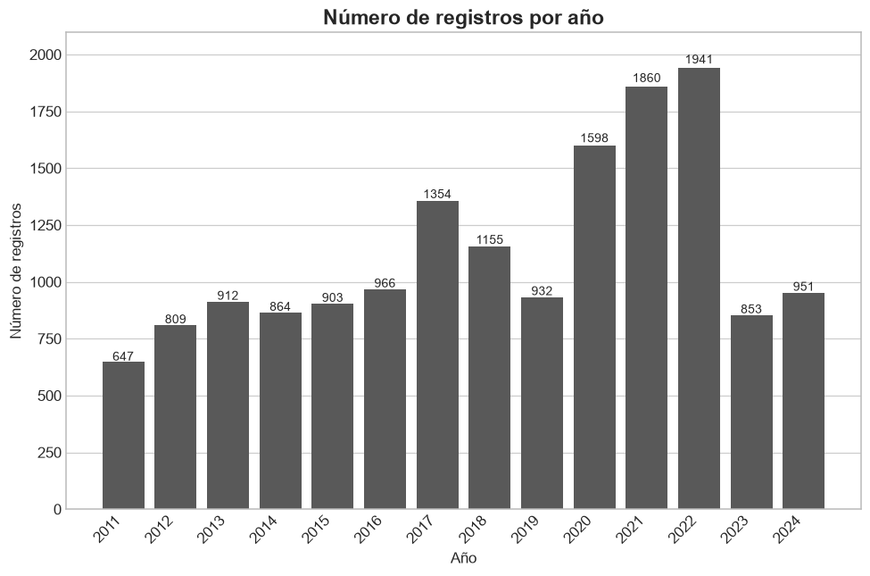

```python
fig, ax = plt.subplots()
ax.bar(frecuencia_anios["Año"].astype(str), frecuencia_anios["n"], color="#595959")
for x, v in zip(frecuencia_anios["Año"].astype(str), frecuencia_anios["n"]): ax.text(x, v * 1.01, str(v), ha="center", fontsize=9)
ax.set_ylim(0, frecuencia_anios["n"].max() * 1.08)
ax.set_title("Número de registros por año", fontweight="bold"); ax.set_xlabel("Año"); ax.set_ylabel("Número de registros")
plt.xticks(rotation=45, ha="right"); ax.grid(axis="x", visible=False)
plt.tight_layout(); plt.show()
```

## 1.3 Estadística descriptiva y distribución de variables ambientales

```python
estadistica_variables = df.groupby("Variable", as_index=False).agg(n=("Promedio", "size"), Media=("Promedio", "mean"), Mediana=("Promedio", "median"), Desviacion_Estandar=("Promedio", "std"), Minimo=("Promedio", "min"), Q1=("Promedio", lambda s: s.quantile(0.25)), Q3=("Promedio", lambda s: s.quantile(0.75)), Maximo=("Promedio", "max"))
estadistica_variables
```

|  | Variable | n | Media | Mediana | Desviacion_Estandar | Minimo | Q1 | Q3 | Maximo |
| --- | --- | --- | --- | --- | --- | --- | --- | --- | --- |
| 0 | CO | 719 | 811.864668 | 692.964695 | 487.497846 | 0.8 | 484.600 | 957.203556 | 3294.800000 |
| 1 | DViento | 1099 | 167.279527 | 168.800000 | 99.266649 | 0.4 | 83.650 | 248.300000 | 359.400000 |
| 2 | HAire | 75 | 66.092000 | 71.800000 | 15.987485 | 33.1 | 62.050 | 76.350000 | 92.000000 |
| 3 | HAire10 | 361 | 68.364820 | 69.100000 | 11.248304 | 28.0 | 65.000 | 75.800000 | 87.400000 |
| 4 | HAire2 | 693 | 70.517605 | 71.300000 | 11.260156 | 18.1 | 66.600 | 78.000000 | 90.500000 |
| 5 | NO | 291 | 25.003174 | 20.800000 | 18.907793 | 0.2 | 11.750 | 34.250000 | 97.200000 |
| 6 | NO2 | 644 | 26.459789 | 26.000000 | 12.492855 | 0.5 | 16.500 | 35.600000 | 65.600000 |
| 7 | O3 | 827 | 26.151963 | 25.700000 | 9.170727 | 2.0 | 19.800 | 31.800000 | 65.800000 |
| 8 | P | 673 | 701.680684 | 677.600000 | 116.808434 | 399.1 | 629.900 | 755.500000 | 1010.400000 |
| 9 | PLiquida | 927 | 9.771090 | 1.400000 | 122.038956 | 0.1 | 0.200 | 3.400000 | 3236.700000 |
| 10 | PM10 | 2984 | 37.125716 | 34.600000 | 15.350493 | 4.6 | 27.000 | 44.800000 | 162.300000 |
| 11 | PM2.5 | 1984 | 16.835610 | 15.700000 | 6.886436 | 2.7 | 12.500 | 19.800000 | 68.600000 |
| 12 | PST | 241 | 74.140664 | 72.000000 | 25.793997 | 11.1 | 56.300 | 87.400000 | 162.400000 |
| 13 | RGlobal | 600 | 185.644833 | 178.450000 | 53.865841 | 48.3 | 156.875 | 206.400000 | 431.300000 |
| 14 | RUVb | 66 | 112.395455 | 46.100000 | 111.506138 | 0.6 | 1.900 | 205.850000 | 303.800000 |
| 15 | SO2 | 1066 | 9.427033 | 6.000000 | 10.674381 | 0.1 | 3.400 | 11.000000 | 91.711673 |
| 16 | TAire | 73 | 22.619178 | 22.300000 | 4.039928 | 13.4 | 20.600 | 25.000000 | 33.500000 |
| 17 | TAire10 | 334 | 22.087126 | 22.000000 | 3.369121 | 12.4 | 20.600 | 24.050000 | 32.400000 |
| 18 | TAire2 | 834 | 20.546763 | 21.400000 | 6.169306 | 1.0 | 14.800 | 25.375000 | 44.000000 |
| 19 | VViento | 1254 | 1.370175 | 1.200000 | 0.790983 | 0.1 | 0.900 | 1.700000 | 10.200000 |

### Distribución de las variables ambientales

```python
vars_orden = sorted(df["Variable"].unique())
def panel_boxplots(inicio, fin, subtitulo):
    grupo = vars_orden[inicio:fin]
    filas = int(np.ceil(len(grupo) / 2))
    fig, axes = plt.subplots(filas, 2, figsize=(9, 3.2 * filas))
    axes = np.array(axes).ravel()
    for ax, v in zip(axes, grupo):
        ax.boxplot(df.loc[df["Variable"] == v, "Promedio"].dropna(), widths=0.5)
        ax.set_title(v, fontweight="bold", fontsize=12); ax.set_xticks([]); ax.set_ylabel("Valor promedio"); ax.grid(axis="x", visible=False)
    for ax in axes[len(grupo):]: ax.axis("off")
    fig.suptitle("Distribución de las variables ambientales\n" + subtitulo, fontweight="bold", fontsize=15)
    plt.tight_layout(); plt.show()
```

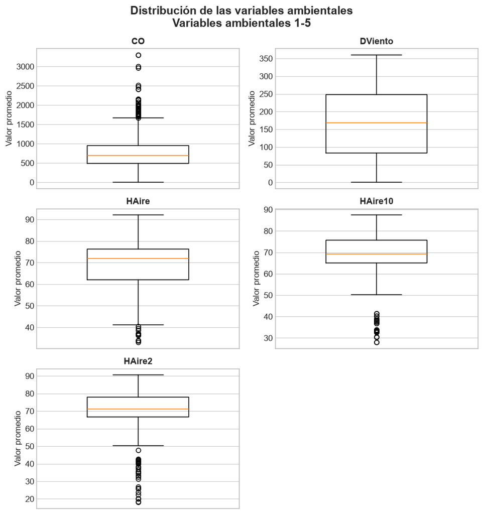

```python
panel_boxplots(0, 5, "Variables ambientales 1-5")
```

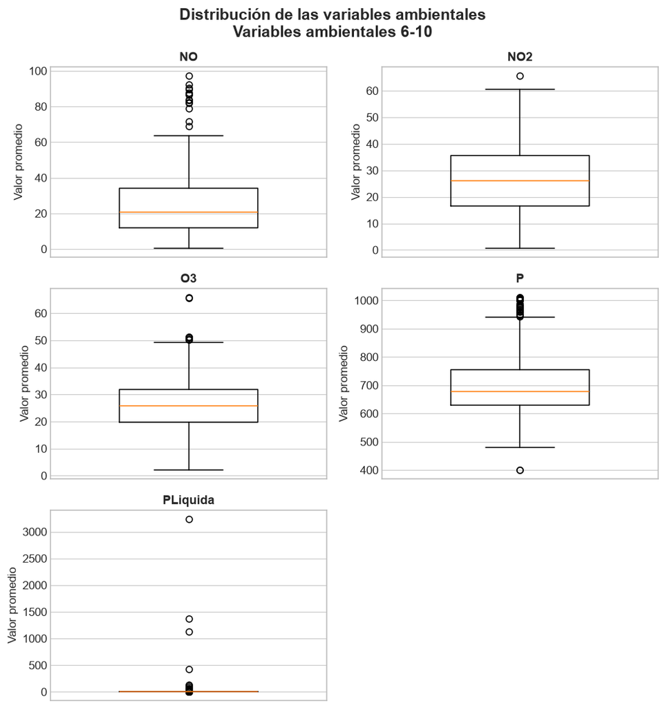

```python
panel_boxplots(5, 10, "Variables ambientales 6-10")
```

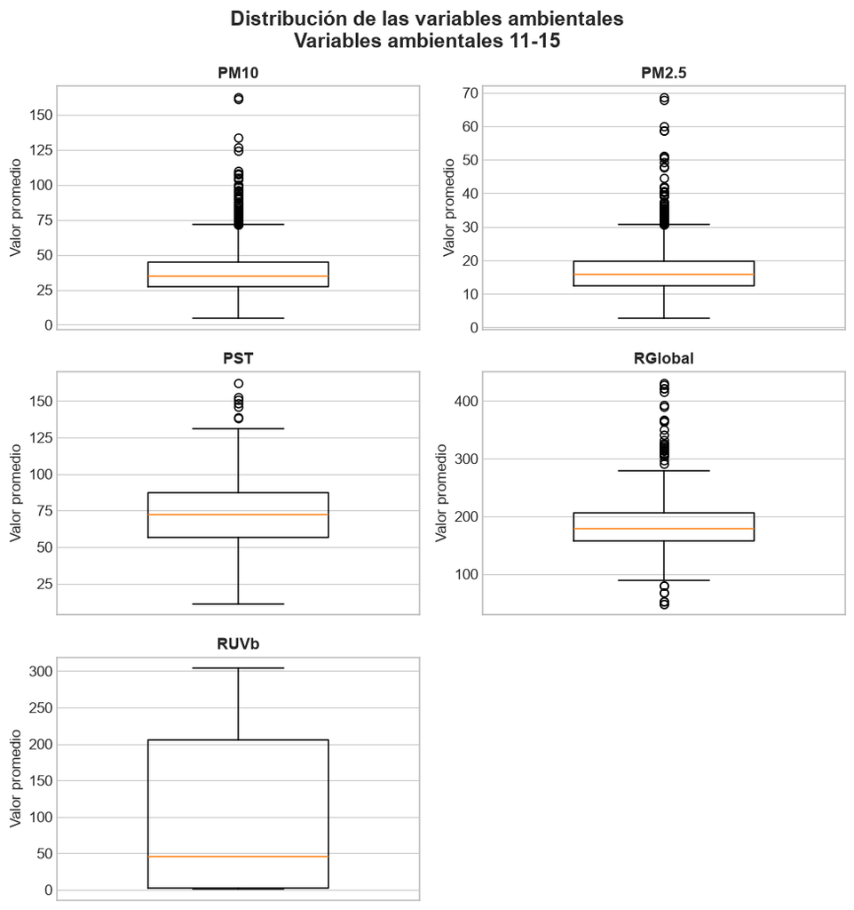

```python
panel_boxplots(10, 15, "Variables ambientales 11-15")
```

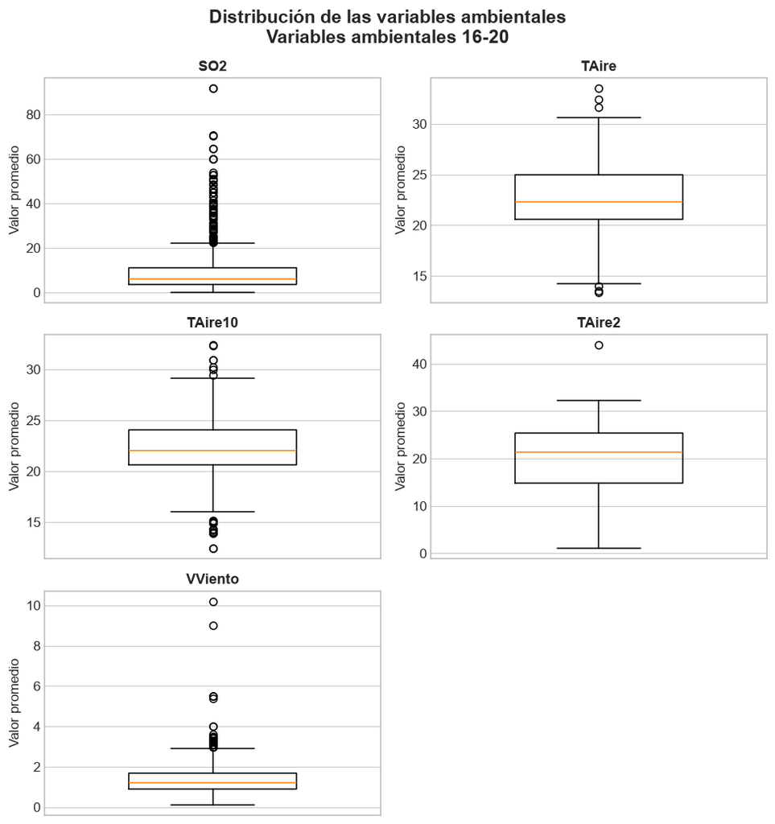

```python
panel_boxplots(15, 20, "Variables ambientales 16-20")
```

### Identificación de valores atípicos

```python
outliers_variables = df.groupby("Variable", as_index=False).agg(Q1=("Promedio", lambda s: s.quantile(0.25)), Q3=("Promedio", lambda s: s.quantile(0.75)))
outliers_variables["IQR"] = outliers_variables["Q3"] - outliers_variables["Q1"]
outliers_variables["Limite_inferior"] = outliers_variables["Q1"] - 1.5 * outliers_variables["IQR"]
outliers_variables["Limite_superior"] = outliers_variables["Q3"] + 1.5 * outliers_variables["IQR"]
```

### Resumen de valores atípicos

```python
tabla(outliers_variables)
```

| Variable | Q1 | Q3 | IQR | Limite_inferior | Limite_superior |
| --- | --- | --- | --- | --- | --- |
| CO | 484.600000 | 957.200000 | 472.600000 | -224.310000 | 1666.110000 |
| DViento | 83.650000 | 248.300000 | 164.650000 | -163.330000 | 495.280000 |
| HAire | 62.050000 | 76.350000 | 14.300000 | 40.600000 | 97.800000 |
| HAire10 | 65.000000 | 75.800000 | 10.800000 | 48.800000 | 92.000000 |
| HAire2 | 66.600000 | 78.000000 | 11.400000 | 49.500000 | 95.100000 |
| NO | 11.750000 | 34.250000 | 22.500000 | -22.000000 | 68.000000 |
| NO2 | 16.500000 | 35.600000 | 19.100000 | -12.150000 | 64.250000 |
| O3 | 19.800000 | 31.800000 | 12.000000 | 1.800000 | 49.800000 |
| P | 629.900000 | 755.500000 | 125.600000 | 441.500000 | 943.900000 |
| PLiquida | 0.200000 | 3.400000 | 3.200000 | -4.600000 | 8.200000 |
| PM10 | 27.000000 | 44.800000 | 17.800000 | 0.300000 | 71.500000 |
| PM2.5 | 12.500000 | 19.800000 | 7.300000 | 1.550000 | 30.750000 |
| PST | 56.300000 | 87.400000 | 31.100000 | 9.650000 | 134.050000 |
| RGlobal | 156.880000 | 206.400000 | 49.530000 | 82.590000 | 280.690000 |
| RUVb | 1.900000 | 205.850000 | 203.950000 | -304.030000 | 511.780000 |
| SO2 | 3.400000 | 11.000000 | 7.600000 | -8.000000 | 22.400000 |
| TAire | 20.600000 | 25.000000 | 4.400000 | 14.000000 | 31.600000 |
| TAire10 | 20.600000 | 24.050000 | 3.450000 | 15.430000 | 29.220000 |
| TAire2 | 14.800000 | 25.380000 | 10.580000 | -1.060000 | 41.240000 |
| VViento | 0.900000 | 1.700000 | 0.800000 | -0.300000 | 2.900000 |

Uso el criterio de Tukey: todo lo que quede por fuera de Q1 menos 1.5 veces el IQR y Q3 más 1.5 veces el IQR lo considero atípico. Es el mismo criterio que apliqué en R.

## 1.4 Representatividad temporal de los datos

```python
representatividad_variables = df.groupby("Variable", as_index=False).agg(Media=("Representatividad Temporal", "mean"), Mediana=("Representatividad Temporal", "median"), Minimo=("Representatividad Temporal", "min"), Maximo=("Representatividad Temporal", "max")).sort_values("Media", ascending=False)
tabla(representatividad_variables)
```

| Variable | Media | Mediana | Minimo | Maximo |
| --- | --- | --- | --- | --- |
| P | 75.370000 | 90.000000 | 0.000000 | 100.000000 |
| TAire10 | 73.990000 | 92.000000 | 0.000000 | 100.000000 |
| RUVb | 73.740000 | 89.500000 | 6.000000 | 100.000000 |
| CO | 72.590000 | 86.000000 | 0.000000 | 100.000000 |
| RGlobal | 71.560000 | 87.000000 | 0.000000 | 100.000000 |
| PLiquida | 69.800000 | 89.000000 | 0.000000 | 100.000000 |
| DViento | 68.590000 | 86.000000 | 0.000000 | 167.000000 |
| HAire10 | 68.130000 | 87.000000 | 0.000000 | 100.000000 |
| O3 | 67.620000 | 80.000000 | 0.000000 | 100.000000 |
| NO | 66.920000 | 85.000000 | 0.000000 | 100.000000 |
| PM2.5 | 66.840000 | 81.000000 | 0.000000 | 103.000000 |
| PST | 66.590000 | 79.000000 | 0.000000 | 101.000000 |
| NO2 | 66.130000 | 77.000000 | 0.000000 | 100.000000 |
| PM10 | 65.970000 | 79.000000 | 0.000000 | 115.000000 |
| TAire2 | 65.570000 | 82.000000 | 0.000000 | 100.000000 |
| HAire2 | 64.130000 | 79.000000 | 0.000000 | 100.000000 |
| SO2 | 63.470000 | 72.000000 | 1.000000 | 100.000000 |
| VViento | 62.860000 | 79.000000 | 0.000000 | 100.000000 |
| HAire | 27.490000 | 15.000000 | 3.000000 | 99.000000 |
| TAire | 23.930000 | 14.500000 | 3.000000 | 90.000000 |

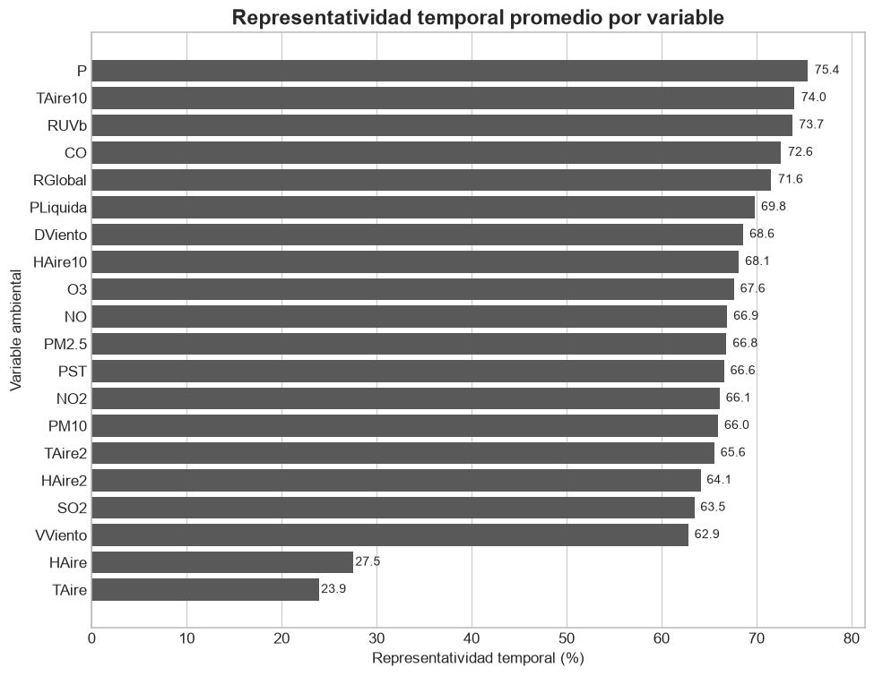

```python
barras_h(representatividad_variables, "Variable", "Media", "Representatividad temporal promedio por variable", "Representatividad temporal (%)", "Variable ambiental", alto=7, dec=1)
```

## 1.5 Distribución geográfica de las estaciones

```python
ubicacion_estaciones = df[["Estación", "Latitud", "Longitud"]].drop_duplicates().sort_values(["Latitud", "Longitud"])
tabla(ubicacion_estaciones.head(20), ["Estación", "Latitud", "Longitud"], decimales=4)
```

| Estación | Latitud | Longitud |
| --- | --- | --- |
| IDSN | 1.216500 | -77.282900 |
| UNIMAR | 1.223800 | -77.283600 |
| CAMPANARIO | 2.438100 | -76.613000 |
| EDIFICIO EDGAR NEGRET | 2.445200 | -76.605400 |
| VIVERO LA FLORIDA | 2.476900 | -76.566700 |
| VIVERO LA FLORIDA* | 2.476900 | -76.566700 |
| ALCALDIA | 2.928900 | -75.289500 |
| CORHUILA | 2.930600 | -75.264900 |
| CORHUILA | 2.930700 | -75.265100 |
| CAM NORTE | 2.962500 | -75.297500 |
| SENA INDUSTRIAL | 2.962500 | -75.284000 |
| CAM NORTE | 2.962600 | -75.297500 |
| CAM NORTE | 2.962600 | -75.297500 |
| SANTANDER | 3.005100 | -76.481600 |
| MUNICIPIO DE SANTANDER DE QUILICHAO | 3.015800 | -76.482900 |
| MUNICIPIO DE SANTANDER DE QUILICHAO* | 3.015800 | -76.482900 |
| CALOTO | 3.034100 | -76.408500 |
| GUACHENÉ | 3.133000 | -76.392300 |
| VILLA RICA | 3.172700 | -76.459000 |
| PUERTO TEJADA | 3.229900 | -76.419300 |

### Distribución por tipo de estación

```python
frecuencia_tipo_estacion = df["Tipo de Estación"].value_counts().rename_axis("Tipo de Estación").reset_index(name="n")
tabla(frecuencia_tipo_estacion, ["Tipo de estación", "Número de registros"])
```

| Tipo de estación | Número de registros |
| --- | --- |
| Fija | 14184 |
| Indicativa | 1560 |

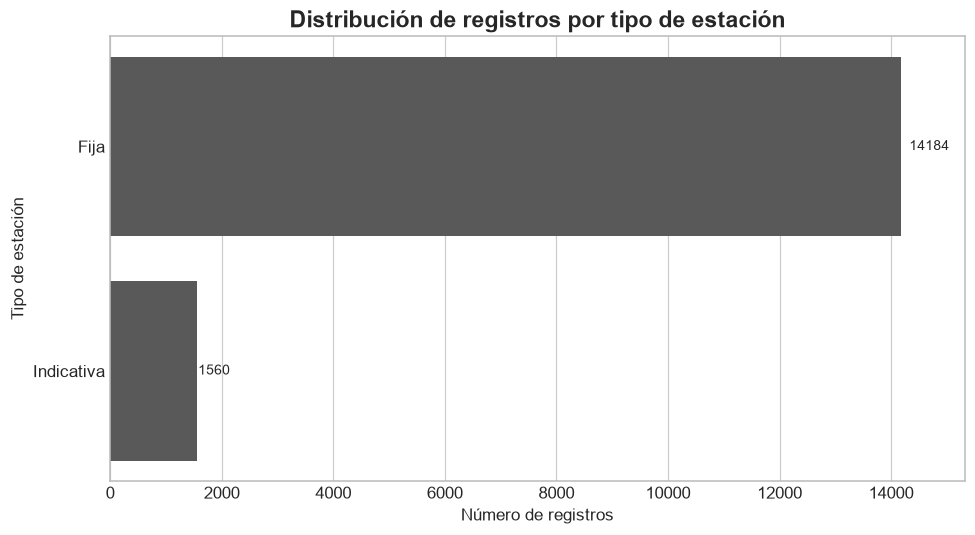

```python
barras_h(frecuencia_tipo_estacion, "Tipo de Estación", "n", "Distribución de registros por tipo de estación", "Número de registros", "Tipo de estación", alto=5)
```

### Distribución por departamento

```python
frecuencia_departamentos = df["Nombre del Departamento"].value_counts().rename_axis("Nombre del Departamento").reset_index(name="n")
tabla(frecuencia_departamentos, ["Departamento", "Número de registros"])
```

| Departamento | Número de registros |
| --- | --- |
| ANTIOQUIA | 4243 |
| BOGOTÁ, D.C. | 2143 |
| VALLE DEL CAUCA | 1434 |
| SANTANDER | 940 |
| BOGOTA, D.C. | 840 |
| CUNDINAMARCA | 757 |
| CESAR | 524 |
| BOYACÁ | 515 |
| MAGDALENA | 493 |
| Bogotá, D.C. | 410 |
| LA GUAJIRA | 382 |
| Cundinamarca | 367 |
| ATLÁNTICO | 327 |
| Antioquia | 322 |
| BOYACA | 282 |
| META | 244 |
| CAUCA | 145 |
| Valle del Cauca | 145 |
| Boyacá | 125 |
| BOLÍVAR | 114 |
| CALDAS | 92 |
| ATLANTICO | 84 |
| RISARALDA | 81 |
| Bolívar | 81 |
| Santander | 66 |
| CÓRDOBA | 63 |
| Magdalena | 63 |
| NORTE DE SANTANDER | 60 |
| TOLIMA | 52 |
| Cesar | 47 |
| Caldas | 44 |
| Atlántico | 30 |
| CORDOBA | 28 |
| HUILA | 25 |
| ARAUCA | 25 |
| Risaralda | 21 |
| La Guajira | 20 |
| Norte de Santander | 19 |
| Meta | 18 |
| QUINDÍO | 15 |
| Córdoba | 12 |
| NARIÑO | 11 |
| CASANARE | 11 |
| CHOCÓ | 7 |
| Cauca | 5 |
| QUINDIO | 4 |
| Huila | 4 |
| Tolima | 3 |
| Quindío | 2 |

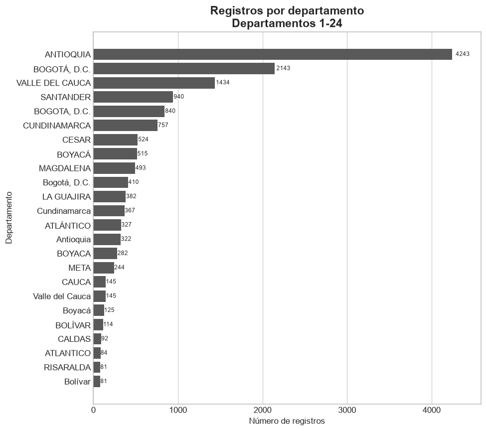

```python
departamentos_1 = frecuencia_departamentos.iloc[0:24]
barras_h(departamentos_1, "Nombre del Departamento", "n", "Registros por departamento", "Número de registros", "Departamento", subtitulo="Departamentos 1-24", alto=8, tam=8)
```

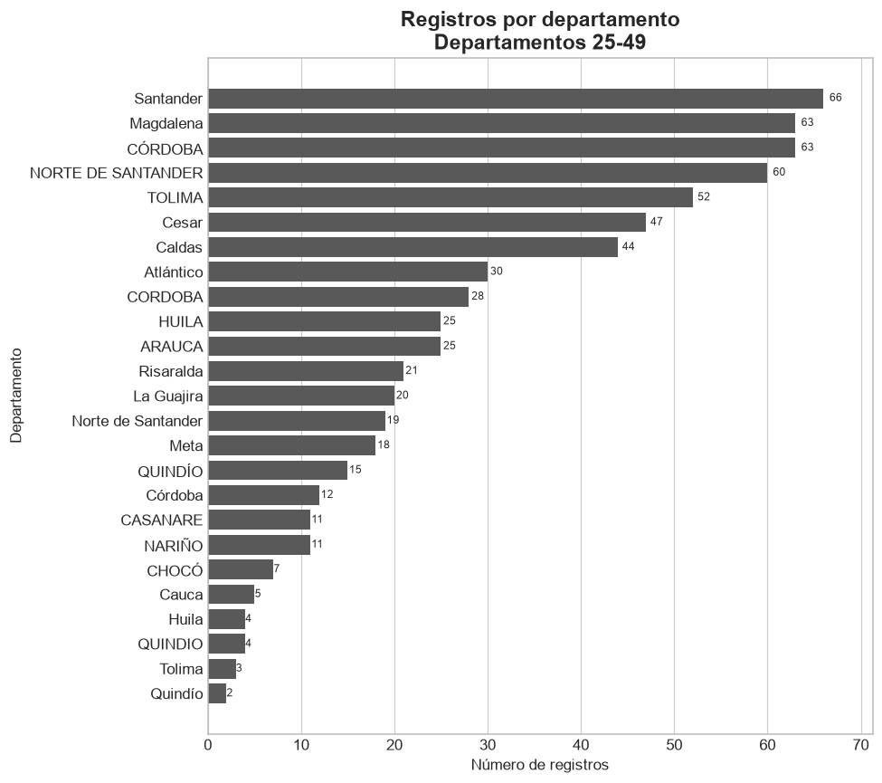

```python
departamentos_2 = frecuencia_departamentos.iloc[24:49]
barras_h(departamentos_2, "Nombre del Departamento", "n", "Registros por departamento", "Número de registros", "Departamento", subtitulo="Departamentos 25-49", alto=8, tam=8)
```

### Distribución por municipio

```python
frecuencia_municipios = df["Nombre del Municipio"].value_counts().rename_axis("Nombre del Municipio").reset_index(name="n")
tabla(frecuencia_municipios, ["Municipio", "Número de registros"])
```

| Municipio | Número de registros |
| --- | --- |
| BOGOTÁ, D.C. | 2143 |
| CALI | 1028 |
| MEDELLÍN | 930 |
| BOGOTA, D.C. | 840 |
| BUCARAMANGA | 653 |
| SOGAMOSO | 446 |
| MEDELLIN | 428 |
| GIRARDOTA | 414 |
| ITAGÜÍ | 395 |
| SANTA MARTA | 343 |
| BARRANQUILLA | 296 |
| NOBSA | 249 |
| VILLAVICENCIO | 244 |
| Bogotá, D.C. | 234 |
| SABANETA | 229 |
| BELLO | 224 |
| CALDAS | 193 |
| Bogota, D.C. | 180 |
| FLORIDABLANCA | 177 |
| LA JAGUA DE IBIRICO | 170 |
| YUMBO | 161 |
| BARBOSA | 155 |
| EL PASO | 146 |
| PALMIRA | 133 |
| ENVIGADO | 122 |
| BARRANCAS | 122 |
| MOSQUERA | 111 |
| SOACHA | 106 |
| SOLEDAD | 99 |
| RIONEGRO | 93 |

[output cut: 309 more lines]

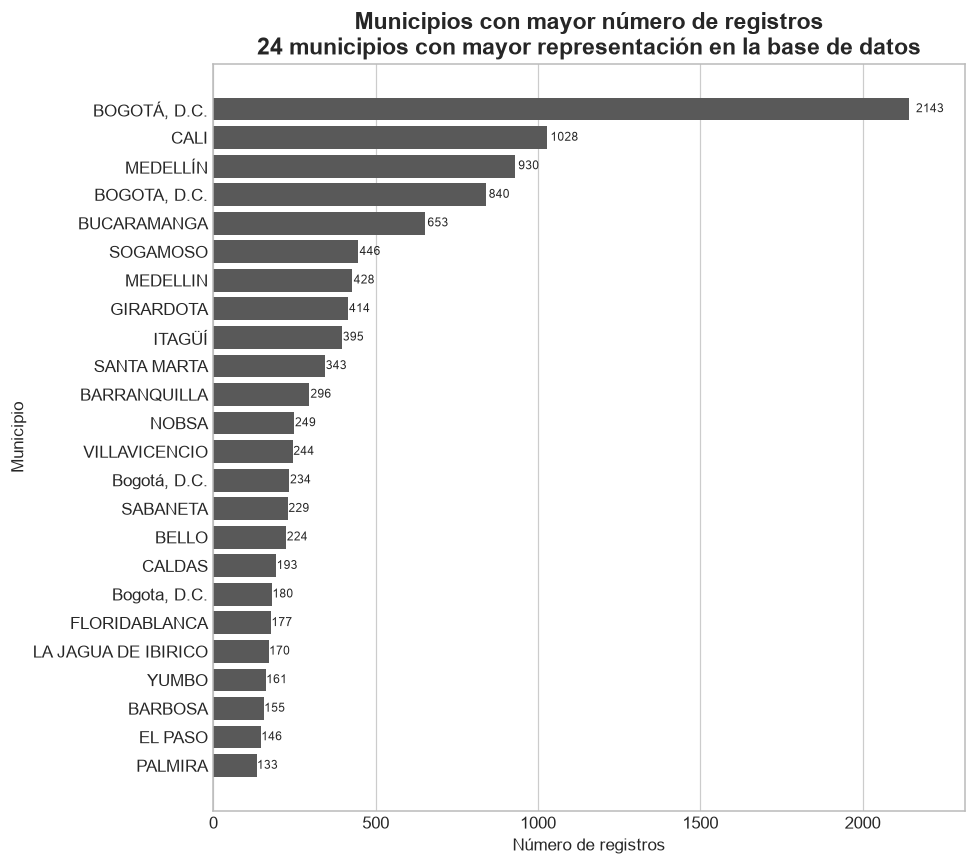

```python
top_municipios = frecuencia_municipios.nlargest(24, "n")
barras_h(top_municipios, "Nombre del Municipio", "n", "Municipios con mayor número de registros", "Número de registros", "Municipio", subtitulo="24 municipios con mayor representación en la base de datos", alto=8, tam=8)
```

## 1.6 Análisis específico de contaminantes

```python
def estadisticos(serie, con_media=True):
    nombres = ["Mínimo", "Primer cuartil", "Mediana", "Media", "Tercer cuartil", "Máximo"]
    valores = [serie.min(), serie.quantile(0.25), serie.median(), serie.mean(), serie.quantile(0.75), serie.max()]
    if not con_media: nombres, valores = ["Mínimo", "Primer cuartil", "Mediana", "Máximo"], [serie.min(), serie.quantile(0.25), serie.median(), serie.max()]
    return pd.DataFrame({"Estadistico": nombres, "Valor": valores})

def promedio_anual(d, nombre): return d.groupby("Año", as_index=False).agg(**{nombre: ("Promedio", "mean"), "Registros": ("Promedio", "size")}).sort_values("Año").reset_index(drop=True)

def grafico_anual(d, col, titulo, subtitulo, ylab, anios=None):
    fig, ax = plt.subplots()
    ax.plot(d["Año"], d[col], linewidth=1.2, marker="o", markersize=6, color="black")
    for x, y in zip(d["Año"], d[col]): ax.text(x, y + (d[col].max() - d[col].min() + 1) * 0.03, f"{y:.1f}", ha="center", fontsize=9)
    ax.set_xticks(list(anios) if anios is not None else sorted(d["Año"].unique()))
    ax.set_ylim(top=d[col].max() * 1.08)
    ax.set_title(titulo + "\n" + subtitulo, fontweight="bold"); ax.set_xlabel("Año"); ax.set_ylabel(ylab)
    plt.xticks(rotation=45, ha="right")
    plt.tight_layout(); plt.show()

def cambio_porcentual(d, col, a1=2011, a2=2024):
    s = d.set_index("Año")[col]
    if a1 not in s.index or a2 not in s.index: return pd.DataFrame({"Periodo": ["N/A"], "Promedio_2011": [np.nan], "Promedio_2024": [np.nan], "Cambio_porcentual": [np.nan]})
    v1, v2 = s.loc[a1], s.loc[a2]
    return pd.DataFrame({"Periodo": [f"{a1}-{a2}"], "Promedio_2011": [v1], "Promedio_2024": [v2], "Cambio_porcentual": [(v2 - v1) / v1 * 100]})
```

### PM10

```python
pm10 = df[df["Variable"] == "PM10"].copy()
print("Registros de PM10:", len(pm10))
estadistica_pm10 = estadisticos(pm10["Promedio"])
tabla(estadistica_pm10, ["Estadístico", "Valor"])
```

```
Registros de PM10: 2984
```

| Estadístico | Valor |
| --- | --- |
| Mínimo | 4.600000 |
| Primer cuartil | 27.000000 |
| Mediana | 34.600000 |
| Media | 37.130000 |
| Tercer cuartil | 44.800000 |
| Máximo | 162.300000 |

```python
pm10_anual = promedio_anual(pm10, "Promedio_PM10")
tabla(pm10_anual, ["Año", "Promedio PM10", "Número de registros"])
```

| Año | Promedio PM10 | Número de registros |
| --- | --- | --- |
| 2011 | 42.660000 | 143 |
| 2012 | 44.600000 | 162 |
| 2013 | 42.070000 | 161 |
| 2014 | 43.640000 | 164 |
| 2015 | 44.400000 | 182 |
| 2016 | 43.650000 | 177 |
| 2017 | 37.700000 | 227 |
| 2018 | 37.030000 | 221 |
| 2019 | 35.780000 | 211 |
| 2020 | 35.900000 | 267 |
| 2021 | 33.200000 | 251 |
| 2022 | 31.880000 | 263 |
| 2023 | 30.890000 | 280 |
| 2024 | 30.830000 | 275 |

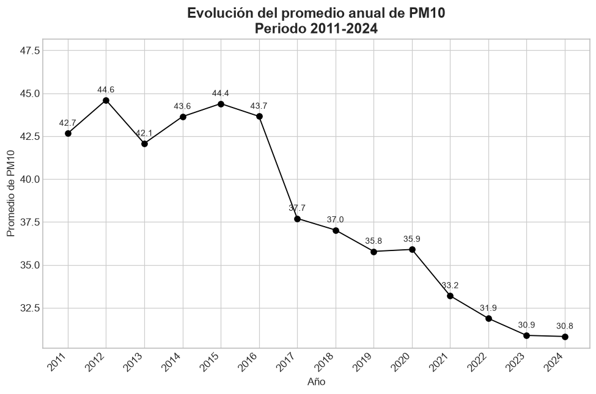

```python
grafico_anual(pm10_anual, "Promedio_PM10", "Evolución del promedio anual de PM10", "Periodo 2011-2024", "Promedio de PM10", anios=range(2011, 2025))
```

```python
tabla_cambio_pm10 = cambio_porcentual(pm10_anual, "Promedio_PM10")
tabla(tabla_cambio_pm10, ["Periodo", "Promedio 2011", "Promedio 2024", "Cambio (%)"])
```

| Periodo | Promedio 2011 | Promedio 2024 | Cambio (%) |
| --- | --- | --- | --- |
| 2011-2024 | 42.660000 | 30.830000 | -27.750000 |

### PM2.5

```python
pm25 = df[df["Variable"] == "PM2.5"].copy()
print("Registros de PM2.5:", len(pm25))
estadistica_pm25 = estadisticos(pm25["Promedio"])
tabla(estadistica_pm25, ["Estadístico", "Valor"])
```

```
Registros de PM2.5: 1984
```

| Estadístico | Valor |
| --- | --- |
| Mínimo | 2.700000 |
| Primer cuartil | 12.500000 |
| Mediana | 15.700000 |
| Media | 16.840000 |
| Tercer cuartil | 19.800000 |
| Máximo | 68.600000 |

```python
pm25_anual = promedio_anual(pm25, "Promedio_PM25")
tabla(pm25_anual, ["Año", "Promedio PM2.5", "Número de registros"])
```

| Año | Promedio PM2.5 | Número de registros |
| --- | --- | --- |
| 2011 | 21.460000 | 19 |
| 2012 | 23.880000 | 33 |
| 2013 | 22.160000 | 40 |
| 2014 | 21.480000 | 55 |
| 2015 | 22.390000 | 59 |
| 2016 | 23.680000 | 65 |
| 2017 | 18.580000 | 142 |
| 2018 | 16.530000 | 162 |
| 2019 | 18.510000 | 139 |
| 2020 | 16.980000 | 233 |
| 2021 | 15.490000 | 240 |
| 2022 | 15.390000 | 258 |
| 2023 | 14.000000 | 268 |
| 2024 | 14.730000 | 271 |

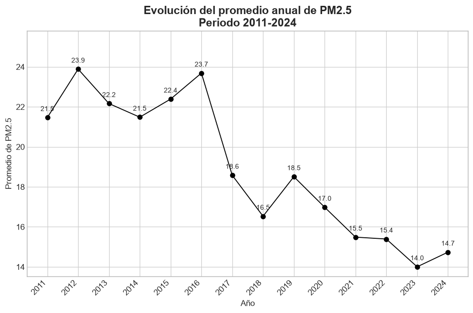

```python
grafico_anual(pm25_anual, "Promedio_PM25", "Evolución del promedio anual de PM2.5", "Periodo 2011-2024", "Promedio de PM2.5", anios=range(2011, 2025))
```

```python
tabla_cambio_pm25 = cambio_porcentual(pm25_anual, "Promedio_PM25")
tabla(tabla_cambio_pm25, ["Periodo", "Promedio 2011", "Promedio 2024", "Cambio (%)"])
```

| Periodo | Promedio 2011 | Promedio 2024 | Cambio (%) |
| --- | --- | --- | --- |
| 2011-2024 | 21.460000 | 14.730000 | -31.350000 |

### NO₂

```python
no2 = df[df["Variable"] == "NO2"].copy()
print("Registros de NO2:", len(no2))
estadistica_no2 = estadisticos(no2["Promedio"])
tabla(estadistica_no2, ["Estadístico", "Valor"])
```

```
Registros de NO2: 644
```

| Estadístico | Valor |
| --- | --- |
| Mínimo | 0.500000 |
| Primer cuartil | 16.500000 |
| Mediana | 26.000000 |
| Media | 26.460000 |
| Tercer cuartil | 35.600000 |
| Máximo | 65.600000 |

```python
no2_anual = promedio_anual(no2, "Promedio_NO2")
tabla(no2_anual, ["Año", "Promedio NO2", "Número de registros"])
```

| Año | Promedio NO2 | Número de registros |
| --- | --- | --- |
| 2011 | 36.280000 | 40 |
| 2012 | 31.770000 | 48 |
| 2013 | 30.520000 | 43 |
| 2014 | 24.850000 | 49 |
| 2015 | 24.360000 | 53 |
| 2016 | 28.280000 | 48 |
| 2017 | 21.320000 | 59 |
| 2018 | 24.270000 | 30 |
| 2019 | 23.320000 | 20 |
| 2020 | 24.390000 | 49 |
| 2021 | 24.310000 | 57 |
| 2022 | 26.130000 | 50 |
| 2023 | 25.050000 | 48 |
| 2024 | 26.880000 | 50 |

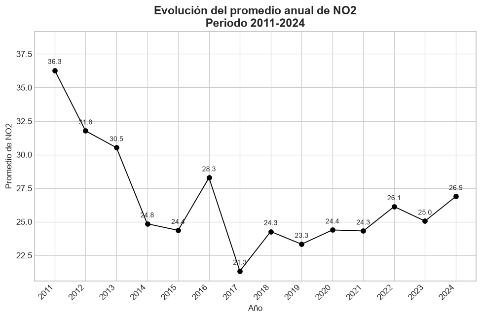

```python
grafico_anual(no2_anual, "Promedio_NO2", "Evolución del promedio anual de NO2", "Periodo 2011-2024", "Promedio de NO2", anios=range(2011, 2025))
```

```python
tabla_cambio_no2 = cambio_porcentual(no2_anual, "Promedio_NO2")
tabla(tabla_cambio_no2, ["Periodo", "Promedio 2011", "Promedio 2024", "Cambio (%)"])
```

| Periodo | Promedio 2011 | Promedio 2024 | Cambio (%) |
| --- | --- | --- | --- |
| 2011-2024 | 36.280000 | 26.880000 | -25.900000 |

### O₃

```python
o3 = df[df["Variable"] == "O3"].copy()
print("Registros de O3:", len(o3))
estadistica_o3 = estadisticos(o3["Promedio"])
tabla(estadistica_o3, ["Estadístico", "Valor"])
```

```
Registros de O3: 827
```

| Estadístico | Valor |
| --- | --- |
| Mínimo | 2.000000 |
| Primer cuartil | 19.800000 |
| Mediana | 25.700000 |
| Media | 26.150000 |
| Tercer cuartil | 31.800000 |
| Máximo | 65.800000 |

```python
o3_anual = promedio_anual(o3, "Promedio_O3")
tabla(o3_anual, ["Año", "Promedio O3", "Número de registros"])
```

| Año | Promedio O3 | Número de registros |
| --- | --- | --- |
| 2011 | 23.940000 | 40 |
| 2012 | 27.550000 | 58 |
| 2013 | 27.860000 | 54 |
| 2014 | 29.010000 | 58 |
| 2015 | 32.640000 | 66 |
| 2016 | 26.740000 | 70 |
| 2017 | 24.230000 | 107 |
| 2018 | 23.940000 | 48 |
| 2019 | 25.000000 | 35 |
| 2020 | 25.920000 | 55 |
| 2021 | 22.680000 | 57 |
| 2022 | 24.930000 | 65 |
| 2023 | 23.530000 | 55 |
| 2024 | 27.290000 | 59 |

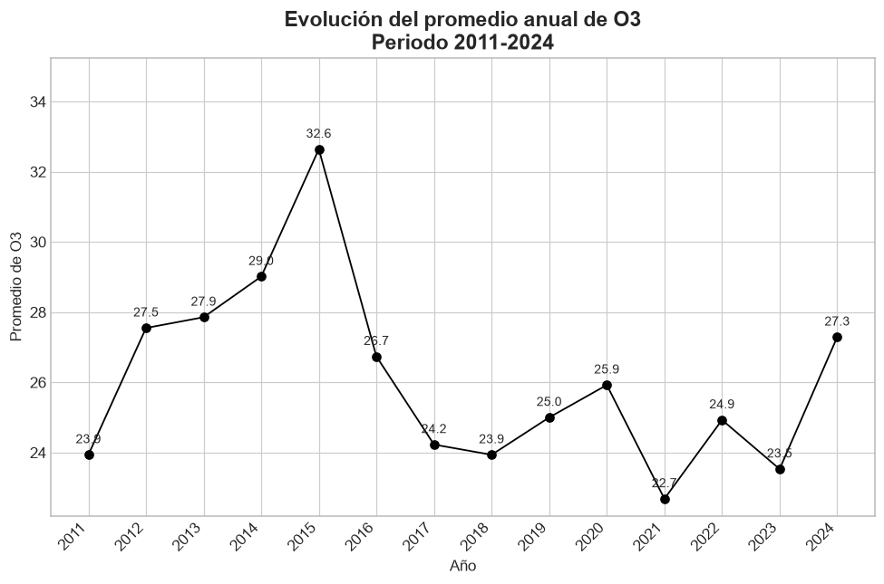

```python
grafico_anual(o3_anual, "Promedio_O3", "Evolución del promedio anual de O3", "Periodo 2011-2024", "Promedio de O3", anios=range(2011, 2025))
```

```python
tabla_cambio_o3 = cambio_porcentual(o3_anual, "Promedio_O3")
tabla(tabla_cambio_o3, ["Periodo", "Promedio 2011", "Promedio 2024", "Cambio (%)"])
```

| Periodo | Promedio 2011 | Promedio 2024 | Cambio (%) |
| --- | --- | --- | --- |
| 2011-2024 | 23.940000 | 27.290000 | 14.000000 |

### SO₂

```python
so2 = df[df["Variable"] == "SO2"].copy()
print("Registros de SO2:", len(so2))
estadistica_so2 = estadisticos(so2["Promedio"])
tabla(estadistica_so2, ["Estadístico", "Valor"])
```

```
Registros de SO2: 1066
```

| Estadístico | Valor |
| --- | --- |
| Mínimo | 0.100000 |
| Primer cuartil | 3.400000 |
| Mediana | 6.000000 |
| Media | 9.430000 |
| Tercer cuartil | 11.000000 |
| Máximo | 91.710000 |

```python
so2_anual = promedio_anual(so2, "Promedio_SO2")
tabla(so2_anual, ["Año", "Promedio SO2", "Número de registros"])
```

| Año | Promedio SO2 | Número de registros |
| --- | --- | --- |
| 2011 | 15.140000 | 43 |
| 2012 | 11.260000 | 39 |
| 2013 | 6.840000 | 39 |
| 2014 | 5.920000 | 33 |
| 2015 | 7.260000 | 36 |
| 2016 | 15.920000 | 52 |
| 2017 | 10.350000 | 96 |
| 2018 | 8.340000 | 60 |
| 2019 | 9.800000 | 70 |
| 2020 | 8.710000 | 113 |
| 2021 | 7.810000 | 122 |
| 2022 | 7.140000 | 116 |
| 2023 | 10.080000 | 122 |
| 2024 | 9.860000 | 125 |

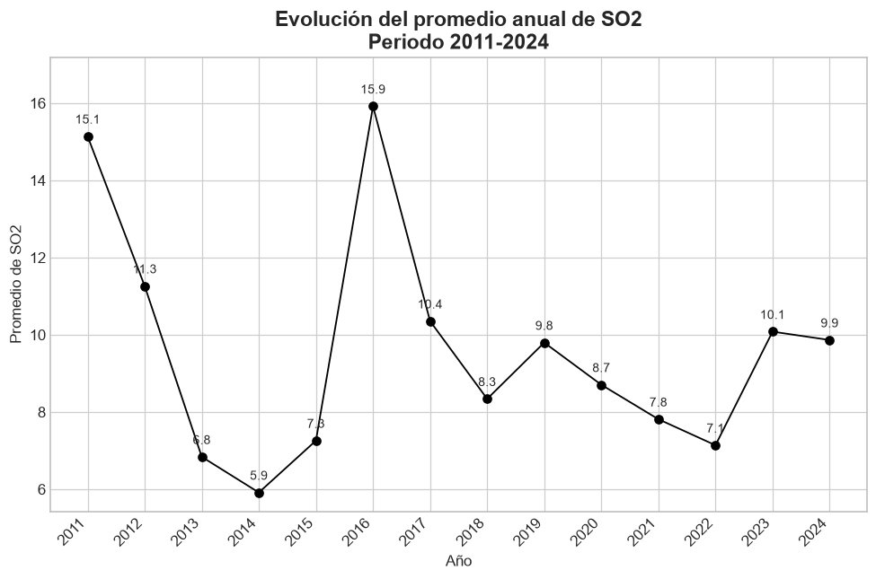

```python
grafico_anual(so2_anual, "Promedio_SO2", "Evolución del promedio anual de SO2", "Periodo 2011-2024", "Promedio de SO2", anios=range(2011, 2025))
```

```python
tabla_cambio_so2 = cambio_porcentual(so2_anual, "Promedio_SO2")
tabla(tabla_cambio_so2, ["Periodo", "Promedio 2011", "Promedio 2024", "Cambio (%)"])
```

| Periodo | Promedio 2011 | Promedio 2024 | Cambio (%) |
| --- | --- | --- | --- |
| 2011-2024 | 15.140000 | 9.860000 | -34.840000 |

### Comparación del cambio porcentual de los contaminantes

```python
cambios = []
for nombre, dat in [("PM10", pm10_anual), ("PM2.5", pm25_anual), ("NO2", no2_anual), ("O3", o3_anual), ("SO2", so2_anual)]:
    s = dat.set_index("Año").iloc[:, 0]
    if 2011 in s.index and 2024 in s.index:
        v1, v2 = s.loc[2011], s.loc[2024]
        cambios.append({"Contaminante": nombre, "Promedio_2011": v1, "Promedio_2024": v2, "Cambio_porcentual": (v2 - v1) / v1 * 100})
comparacion_contaminantes = pd.DataFrame(cambios)
tabla(comparacion_contaminantes, ["Contaminante", "Promedio 2011", "Promedio 2024", "Cambio (%)"])
```

| Contaminante | Promedio 2011 | Promedio 2024 | Cambio (%) |
| --- | --- | --- | --- |
| PM10 | 42.660000 | 30.830000 | -27.750000 |
| PM2.5 | 21.460000 | 14.730000 | -31.350000 |
| NO2 | 36.280000 | 26.880000 | -25.900000 |
| O3 | 23.940000 | 27.290000 | 14.000000 |
| SO2 | 15.140000 | 9.860000 | -34.840000 |

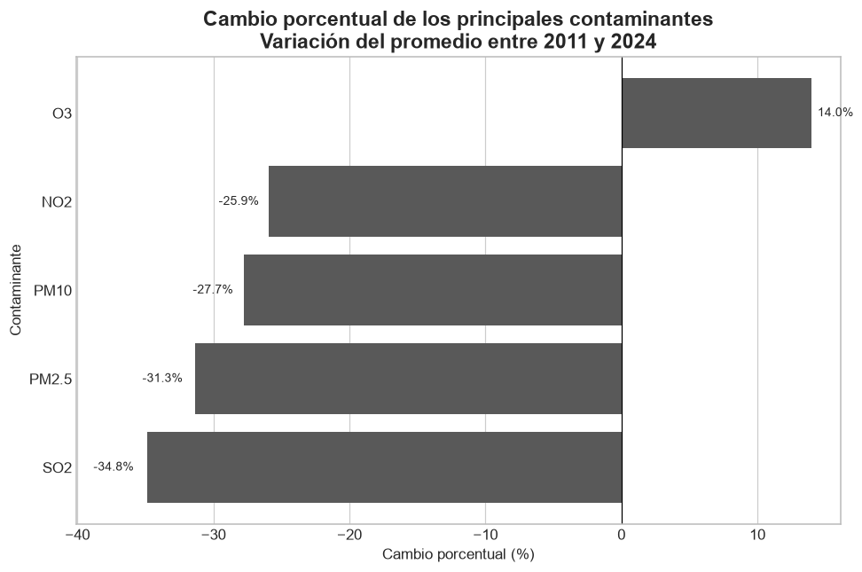

```python
d = comparacion_contaminantes.sort_values("Cambio_porcentual")
fig, ax = plt.subplots()
ax.barh(d["Contaminante"], d["Cambio_porcentual"], color="#595959")
for y, v in zip(d["Contaminante"], d["Cambio_porcentual"]): ax.text(v * 1.03, y, f"{v:.1f}%", va="center", ha="right" if v < 0 else "left", fontsize=9)
ax.set_xlim(d["Cambio_porcentual"].min() * 1.15, d["Cambio_porcentual"].max() * 1.15)
ax.axvline(0, color="black", linewidth=0.8)
ax.set_title("Cambio porcentual de los principales contaminantes\nVariación del promedio entre 2011 y 2024", fontweight="bold")
ax.set_xlabel("Cambio porcentual (%)"); ax.set_ylabel("Contaminante"); ax.grid(axis="y", visible=False)
plt.tight_layout(); plt.show()
```

## 1.7 Análisis de variables meteorológicas

### Temperatura del aire (TAire)

```python
taire = df[df["Variable"] == "TAire"].copy()
print("Registros de TAire:", len(taire))
estadistica_taire = estadisticos(taire["Promedio"])
tabla(estadistica_taire, ["Estadístico", "Valor"])
```

```
Registros de TAire: 73
```

| Estadístico | Valor |
| --- | --- |
| Mínimo | 13.400000 |
| Primer cuartil | 20.600000 |
| Mediana | 22.300000 |
| Media | 22.620000 |
| Tercer cuartil | 25.000000 |
| Máximo | 33.500000 |

```python
taire_anual = promedio_anual(taire, "Promedio_TAire")
tabla(taire_anual, ["Año", "Promedio TAire", "Número de registros"])
```

| Año | Promedio TAire | Número de registros |
| --- | --- | --- |
| 2011 | 20.900000 | 2 |
| 2012 | 21.970000 | 6 |
| 2013 | 22.080000 | 8 |
| 2017 | 22.310000 | 34 |
| 2018 | 23.120000 | 17 |
| 2019 | 24.880000 | 6 |

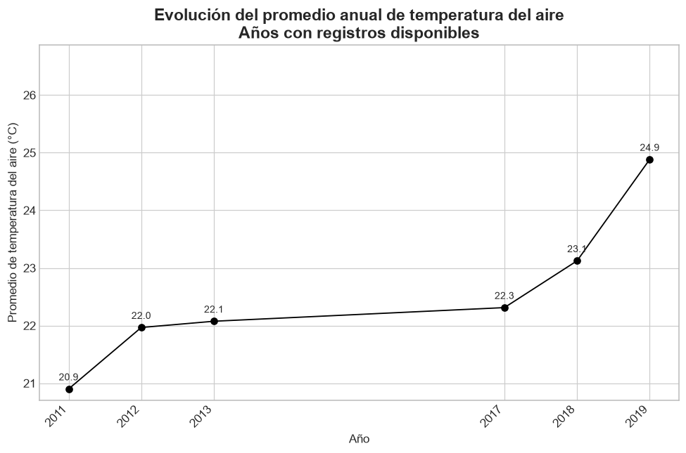

```python
grafico_anual(taire_anual, "Promedio_TAire", "Evolución del promedio anual de temperatura del aire", "Años con registros disponibles", "Promedio de temperatura del aire (°C)")
```

### Humedad relativa del aire (HAire)

```python
haire = df[df["Variable"] == "HAire"].copy()
print("Registros de HAire:", len(haire))
estadistica_haire = estadisticos(haire["Promedio"])
tabla(estadistica_haire, ["Estadístico", "Valor"])
```

```
Registros de HAire: 75
```

| Estadístico | Valor |
| --- | --- |
| Mínimo | 33.100000 |
| Primer cuartil | 62.050000 |
| Mediana | 71.800000 |
| Media | 66.090000 |
| Tercer cuartil | 76.350000 |
| Máximo | 92.000000 |

```python
haire_anual = promedio_anual(haire, "Promedio_HAire")
tabla(haire_anual, ["Año", "Promedio HAire", "Número de registros"])
```

| Año | Promedio HAire | Número de registros |
| --- | --- | --- |
| 2011 | 71.900000 | 4 |
| 2012 | 70.700000 | 2 |
| 2013 | 72.550000 | 2 |
| 2014 | 68.340000 | 5 |
| 2017 | 65.510000 | 36 |
| 2018 | 62.390000 | 20 |
| 2019 | 72.530000 | 6 |

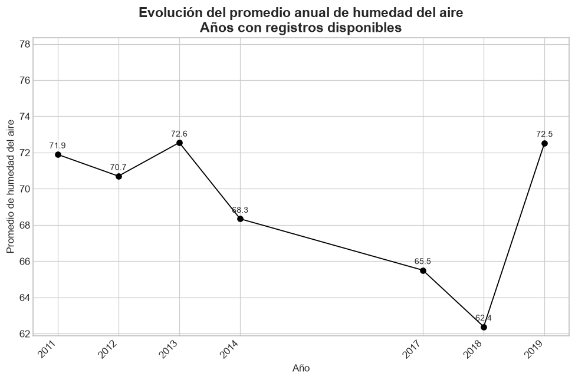

```python
grafico_anual(haire_anual, "Promedio_HAire", "Evolución del promedio anual de humedad del aire", "Años con registros disponibles", "Promedio de humedad del aire")
```

### Velocidad del viento (VViento)

```python
vviento = df[df["Variable"] == "VViento"].copy()
print("Registros de VViento:", len(vviento))
estadistica_vviento = estadisticos(vviento["Promedio"])
tabla(estadistica_vviento, ["Estadístico", "Valor"])
```

```
Registros de VViento: 1254
```

| Estadístico | Valor |
| --- | --- |
| Mínimo | 0.100000 |
| Primer cuartil | 0.900000 |
| Mediana | 1.200000 |
| Media | 1.370000 |
| Tercer cuartil | 1.700000 |
| Máximo | 10.200000 |

```python
vviento_anual = promedio_anual(vviento, "Promedio_VViento")
tabla(vviento_anual, ["Año", "Promedio VViento", "Número de registros"])
```

| Año | Promedio VViento | Número de registros |
| --- | --- | --- |
| 2011 | 1.410000 | 52 |
| 2012 | 1.560000 | 61 |
| 2013 | 1.690000 | 89 |
| 2014 | 1.600000 | 89 |
| 2015 | 1.450000 | 91 |
| 2016 | 1.230000 | 100 |
| 2017 | 1.260000 | 115 |
| 2018 | 1.470000 | 89 |
| 2019 | 1.390000 | 74 |
| 2020 | 1.310000 | 136 |
| 2021 | 1.230000 | 174 |
| 2022 | 1.260000 | 184 |

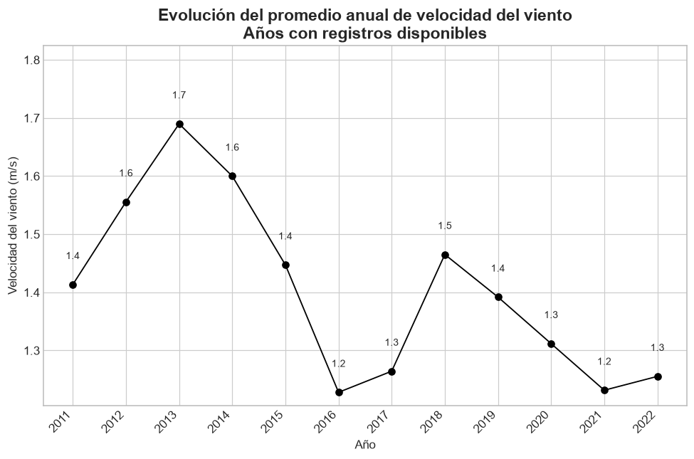

```python
grafico_anual(vviento_anual, "Promedio_VViento", "Evolución del promedio anual de velocidad del viento", "Años con registros disponibles", "Velocidad del viento (m/s)")
```

### Presión atmosférica (P)

```python
presion = df[df["Variable"] == "P"].copy()
print("Registros de P:", len(presion))
estadistica_presion = estadisticos(presion["Promedio"])
tabla(estadistica_presion, ["Estadístico", "Valor"])
```

```
Registros de P: 673
```

| Estadístico | Valor |
| --- | --- |
| Mínimo | 399.100000 |
| Primer cuartil | 629.900000 |
| Mediana | 677.600000 |
| Media | 701.680000 |
| Tercer cuartil | 755.500000 |
| Máximo | 1010.400000 |

```python
presion_anual = promedio_anual(presion, "Promedio_P")
tabla(presion_anual, ["Año", "Promedio de presión", "Número de registros"])
```

| Año | Promedio de presión | Número de registros |
| --- | --- | --- |
| 2011 | 634.880000 | 23 |
| 2012 | 636.120000 | 31 |
| 2013 | 631.590000 | 30 |
| 2014 | 639.330000 | 32 |
| 2015 | 651.300000 | 41 |
| 2016 | 726.740000 | 40 |
| 2017 | 753.810000 | 54 |
| 2018 | 851.040000 | 50 |
| 2019 | 843.070000 | 31 |
| 2020 | 719.270000 | 95 |
| 2021 | 664.450000 | 120 |
| 2022 | 676.770000 | 126 |

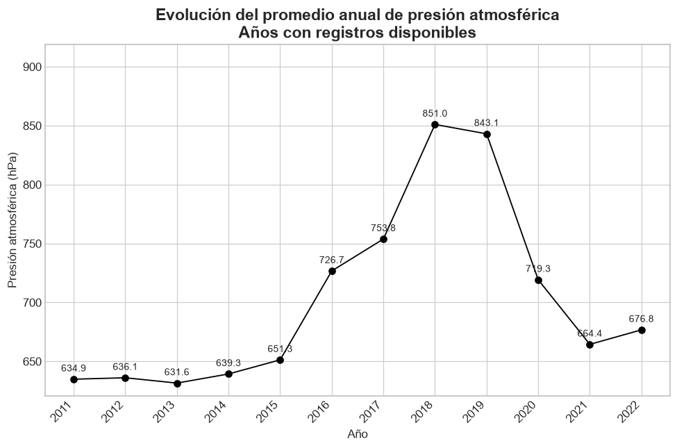

```python
grafico_anual(presion_anual, "Promedio_P", "Evolución del promedio anual de presión atmosférica", "Años con registros disponibles", "Presión atmosférica (hPa)")
```

### Precipitación líquida (PLiquida)

```python
pliquida = df[df["Variable"] == "PLiquida"].copy()
print("Registros de PLiquida:", len(pliquida))
estadistica_pliquida = estadisticos(pliquida["Promedio"])
tabla(estadistica_pliquida, ["Estadístico", "Valor"])
```

```
Registros de PLiquida: 927
```

| Estadístico | Valor |
| --- | --- |
| Mínimo | 0.100000 |
| Primer cuartil | 0.200000 |
| Mediana | 1.400000 |
| Media | 9.770000 |
| Tercer cuartil | 3.400000 |
| Máximo | 3236.700000 |

```python
pliquida_anual = promedio_anual(pliquida, "Promedio_PLiquida")
tabla(pliquida_anual, ["Año", "Promedio de precipitación", "Número de registros"])
```

| Año | Promedio de precipitación | Número de registros |
| --- | --- | --- |
| 2011 | 3.290000 | 58 |
| 2012 | 1.950000 | 66 |
| 2013 | 2.580000 | 77 |
| 2014 | 3.060000 | 61 |
| 2015 | 2.130000 | 70 |
| 2016 | 4.560000 | 84 |
| 2017 | 56.530000 | 63 |
| 2018 | 2.970000 | 60 |
| 2019 | 34.790000 | 45 |
| 2020 | 16.460000 | 89 |
| 2021 | 6.540000 | 123 |
| 2022 | 1.880000 | 131 |

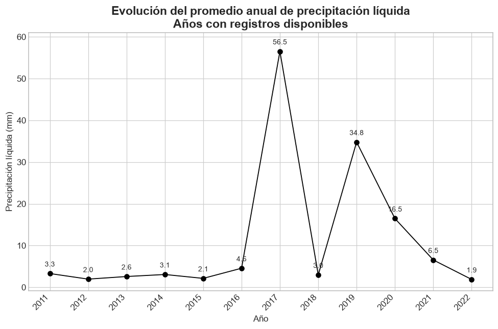

```python
grafico_anual(pliquida_anual, "Promedio_PLiquida", "Evolución del promedio anual de precipitación líquida", "Años con registros disponibles", "Precipitación líquida (mm)")
```

### Radiación global (RGlobal)

```python
rglobal = df[df["Variable"] == "RGlobal"].copy()
print("Registros de RGlobal:", len(rglobal))
estadistica_rglobal = estadisticos(rglobal["Promedio"])
tabla(estadistica_rglobal, ["Estadístico", "Valor"])
```

```
Registros de RGlobal: 600
```

| Estadístico | Valor |
| --- | --- |
| Mínimo | 48.300000 |
| Primer cuartil | 156.880000 |
| Mediana | 178.450000 |
| Media | 185.640000 |
| Tercer cuartil | 206.400000 |
| Máximo | 431.300000 |

```python
rglobal_anual = promedio_anual(rglobal, "Promedio_RGlobal")
tabla(rglobal_anual, ["Año", "Promedio RGlobal", "Número de registros"])
```

| Año | Promedio RGlobal | Número de registros |
| --- | --- | --- |
| 2011 | 165.150000 | 19 |
| 2012 | 177.640000 | 41 |
| 2013 | 178.480000 | 43 |
| 2014 | 177.210000 | 42 |
| 2015 | 195.780000 | 38 |
| 2016 | 194.610000 | 34 |
| 2017 | 192.430000 | 71 |
| 2018 | 185.830000 | 61 |
| 2019 | 190.720000 | 43 |
| 2020 | 199.210000 | 53 |
| 2021 | 183.370000 | 74 |
| 2022 | 178.580000 | 81 |

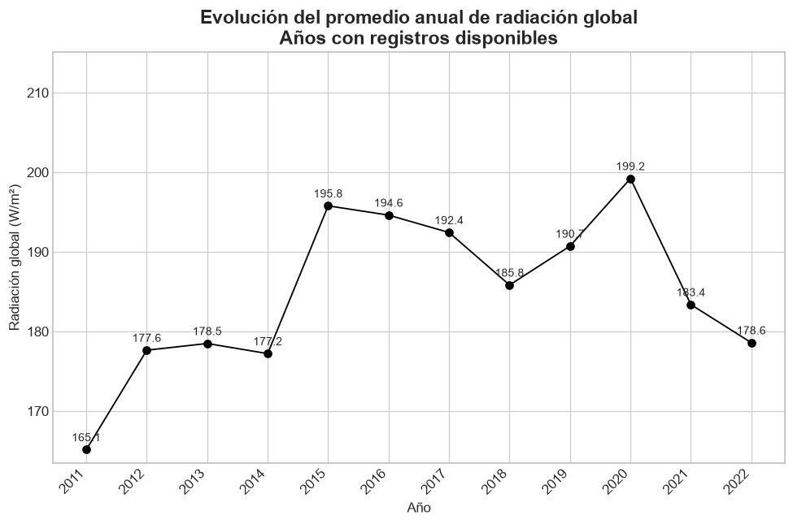

```python
grafico_anual(rglobal_anual, "Promedio_RGlobal", "Evolución del promedio anual de radiación global", "Años con registros disponibles", "Radiación global (W/m²)")
```

### Radiación ultravioleta B (RUVb)

```python
ruvb = df[df["Variable"] == "RUVb"].copy()
print("Registros de RUVb:", len(ruvb))
estadistica_ruvb = estadisticos(ruvb["Promedio"])
tabla(estadistica_ruvb, ["Estadístico", "Valor"])
```

```
Registros de RUVb: 66
```

| Estadístico | Valor |
| --- | --- |
| Mínimo | 0.600000 |
| Primer cuartil | 1.900000 |
| Mediana | 46.100000 |
| Media | 112.400000 |
| Tercer cuartil | 205.850000 |
| Máximo | 303.800000 |

```python
ruvb_anual = promedio_anual(ruvb, "Promedio_RUVb")
tabla(ruvb_anual, ["Año", "Promedio RUVb", "Número de registros"])
```

| Año | Promedio RUVb | Número de registros |
| --- | --- | --- |
| 2011 | 0.600000 | 2 |
| 2012 | 0.600000 | 2 |
| 2013 | 0.600000 | 2 |
| 2014 | 0.600000 | 2 |
| 2017 | 1.700000 | 4 |
| 2018 | 1.750000 | 4 |
| 2019 | 153.120000 | 12 |
| 2020 | 135.390000 | 14 |
| 2021 | 132.160000 | 14 |
| 2022 | 181.630000 | 10 |

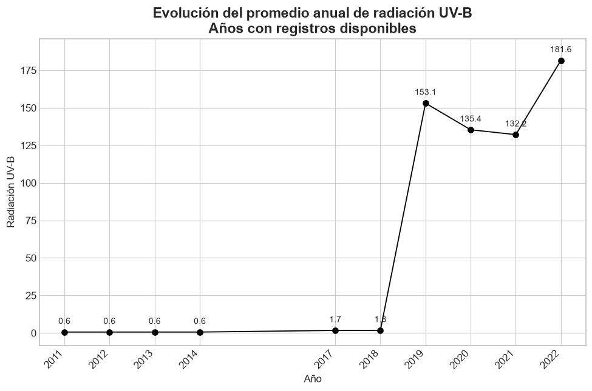

```python
grafico_anual(ruvb_anual, "Promedio_RUVb", "Evolución del promedio anual de radiación UV-B", "Años con registros disponibles", "Radiación UV-B")
```

## 1.8 Análisis de correlaciones

### Preparación de los datos

```python
datos_correlacion = df.groupby(["Año", "Variable"], as_index=False)["Promedio"].mean().pivot(index="Año", columns="Variable", values="Promedio").reset_index().rename_axis(None, axis=1)
datos_correlacion.head()
```

|  | Año | CO | DViento | HAire | HAire10 | HAire2 | NO | NO2 | O3 | P | ... | PM10 | PM2.5 | PST | RGlobal | RUVb | SO2 | TAire | TAire10 | TAire2 | VViento |
| --- | --- | --- | --- | --- | --- | --- | --- | --- | --- | --- | --- | --- | --- | --- | --- | --- | --- | --- | --- | --- | --- |
| 0 | 2011 | 1159.331250 | 183.766667 | 71.90 | 74.066667 | 72.732000 | 33.830769 | 36.280000 | 23.937500 | 634.882609 | ... | 42.664336 | 21.463158 | 72.997500 | 165.147368 | 0.6 | 15.139535 | 20.900000 | 24.300000 | 18.330233 | 1.413462 |
| 1 | 2012 | 1154.315625 | 173.567442 | 70.70 | 68.366667 | 69.990741 | 29.894444 | 31.770833 | 27.548276 | 636.119355 | ... | 44.601852 | 23.884848 | 76.111429 | 177.641463 | 0.6 | 11.261538 | 21.966667 | 23.866667 | 20.075758 | 1.555738 |
| 2 | 2013 | 1186.396667 | 139.741538 | 72.55 | 69.218519 | 67.887500 | 29.331579 | 30.518605 | 27.855556 | 631.593333 | ... | 42.072671 | 22.162500 | 70.654286 | 178.483721 | 0.6 | 6.838462 | 22.075000 | 21.688462 | 20.833333 | 1.689888 |
| 3 | 2014 | 1219.070000 | 136.083077 | 68.34 | 68.829167 | 64.920588 | 32.156250 | 24.846939 | 29.013793 | 639.325000 | ... | 43.639634 | 21.481818 | 75.490909 | 177.214286 | 0.6 | 5.915152 | NaN | 21.539286 | 21.147727 | 1.600000 |
| 4 | 2015 | 1019.250000 | 144.307937 | NaN | 66.184615 | 59.509677 | 27.485000 | 24.356604 | 32.640909 | 651.304878 | ... | 44.396154 | 22.386441 | 80.233333 | 195.776316 | NaN | 7.258333 | NaN | 21.850000 | 20.958974 | 1.447253 |

5 rows × 21 columns

### Matriz de correlaciones

```python
variables_eda = ["PM10", "PM2.5", "NO2", "SO2", "O3", "TAire", "HAire", "VViento", "P", "PLiquida", "RGlobal", "RUVb"]
matriz_correlacion = datos_correlacion[[v for v in variables_eda if v in datos_correlacion.columns]].corr(method="pearson")
matriz_correlacion.round(2)
```

|  | PM10 | PM2.5 | NO2 | SO2 | O3 | TAire | HAire | VViento | P | PLiquida | RGlobal | RUVb |
| --- | --- | --- | --- | --- | --- | --- | --- | --- | --- | --- | --- | --- |
| PM10 | 1.00 | 0.97 | 0.44 | 0.23 | 0.59 | -0.79 | 0.39 | 0.58 | -0.44 | -0.31 | -0.17 | -0.83 |
| PM2.5 | 0.97 | 1.00 | 0.49 | 0.31 | 0.59 | -0.58 | 0.66 | 0.51 | -0.44 | -0.25 | -0.15 | -0.70 |
| NO2 | 0.44 | 0.49 | 1.00 | 0.52 | 0.05 | -0.73 | 0.57 | 0.35 | -0.55 | -0.53 | -0.71 | -0.39 |
| SO2 | 0.23 | 0.31 | 0.52 | 1.00 | -0.27 | -0.48 | 0.25 | -0.34 | 0.08 | 0.08 | -0.08 | -0.26 |
| O3 | 0.59 | 0.59 | 0.05 | -0.27 | 1.00 | -0.12 | 0.35 | 0.51 | -0.42 | -0.32 | 0.21 | -0.35 |
| TAire | -0.79 | -0.58 | -0.73 | -0.48 | -0.12 | 1.00 | -0.07 | -0.20 | 0.82 | 0.40 | 0.76 | 0.85 |
| HAire | 0.39 | 0.66 | 0.57 | 0.25 | 0.35 | -0.07 | 1.00 | 0.34 | -0.50 | -0.17 | -0.43 | 0.37 |
| VViento | 0.58 | 0.51 | 0.35 | -0.34 | 0.51 | -0.20 | 0.34 | 1.00 | -0.31 | -0.35 | -0.42 | -0.65 |
| P | -0.44 | -0.44 | -0.55 | 0.08 | -0.42 | 0.82 | -0.50 | -0.31 | 1.00 | 0.51 | 0.49 | 0.21 |
| PLiquida | -0.31 | -0.25 | -0.53 | 0.08 | -0.32 | 0.40 | -0.17 | -0.35 | 0.51 | 1.00 | 0.42 | 0.07 |
| RGlobal | -0.17 | -0.15 | -0.71 | -0.08 | 0.21 | 0.76 | -0.43 | -0.42 | 0.49 | 0.42 | 1.00 | 0.40 |
| RUVb | -0.83 | -0.70 | -0.39 | -0.26 | -0.35 | 0.85 | 0.37 | -0.65 | 0.21 | 0.07 | 0.40 | 1.00 |

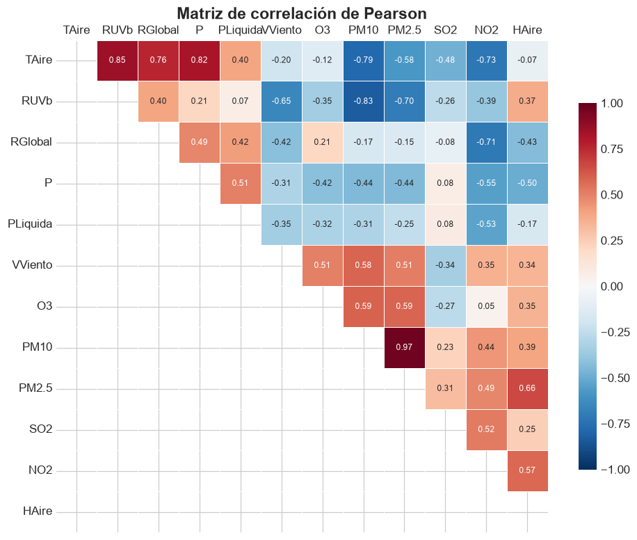

```python
distancia = 1 - matriz_correlacion
orden = leaves_list(linkage(squareform(distancia.values, checks=False), method="complete"))
m = matriz_correlacion.iloc[orden, orden]
mascara = np.tril(np.ones(m.shape, dtype=bool))
fig, ax = plt.subplots(figsize=(9, 7.5))
sns.heatmap(m, mask=mascara, annot=True, fmt=".2f", annot_kws={"size": 8}, cmap="RdBu_r", vmin=-1, vmax=1, square=True, linewidths=0.5, cbar_kws={"shrink": 0.7}, ax=ax)
ax.set_title("Matriz de correlación de Pearson", fontweight="bold")
plt.xticks(rotation=45, ha="left"); ax.xaxis.tick_top()
plt.tight_layout(); plt.show()
```

### Tabla de correlaciones y fuerza de asociación

```python
def fuerza(r):
    a = abs(r)
    if a >= 0.80: return "Muy fuerte"
    elif a >= 0.60: return "Fuerte"
    elif a >= 0.40: return "Moderada"
    elif a >= 0.20: return "Débil"
    else: return "Muy débil"
correlaciones_todas = datos_correlacion.select_dtypes("number").dropna().corr(method="pearson").rename_axis("Variable1").reset_index().melt(id_vars="Variable1", var_name="Variable2", value_name="Correlacion")
correlaciones_todas = correlaciones_todas[correlaciones_todas["Variable1"] != correlaciones_todas["Variable2"]].copy()
correlaciones_todas["Relacion"] = correlaciones_todas["Variable1"] + " vs. " + correlaciones_todas["Variable2"]
correlaciones_todas["Fuerza"] = correlaciones_todas["Correlacion"].apply(fuerza)
correlaciones_todas = correlaciones_todas[["Relacion", "Correlacion", "Fuerza"]].drop_duplicates(subset="Relacion").reset_index(drop=True)
correlaciones_todas.head(10)
```

|  | Relacion | Correlacion | Fuerza |
| --- | --- | --- | --- |
| 0 | CO vs. Año | -0.899201 | Muy fuerte |
| 1 | DViento vs. Año | 0.408605 | Moderada |
| 2 | HAire vs. Año | -0.499833 | Moderada |
| 3 | HAire10 vs. Año | -0.365553 | Débil |
| 4 | HAire2 vs. Año | -0.851093 | Muy fuerte |
| 5 | NO vs. Año | -0.798901 | Fuerte |
| 6 | NO2 vs. Año | -0.935289 | Muy fuerte |
| 7 | O3 vs. Año | -0.448068 | Moderada |
| 8 | P vs. Año | 0.960602 | Muy fuerte |
| 9 | PLiquida vs. Año | 0.598982 | Moderada |

```python
def color_corr(x):
    if x >= 0.80: return "#81C784"
    elif x >= 0.60: return "#A5D6A7"
    elif x >= 0.40: return "#FFF59D"
    elif x >= 0.20: return "#FFE0B2"
    elif x <= -0.80: return "#E57373"
    elif x <= -0.60: return "#EF9A9A"
    elif x <= -0.40: return "#FFCC80"
    elif x <= -0.20: return "#FFE0B2"
    else: return "#E0E0E0"
estilos = pd.DataFrame("", index=correlaciones_todas.index, columns=correlaciones_todas.columns)
estilos["Correlacion"] = ["background-color: " + color_corr(v) + "; color: black" for v in correlaciones_todas["Correlacion"]]
estilos["Fuerza"] = estilos["Correlacion"]
correlaciones_todas.round(2).rename(columns={"Relacion": "Relación", "Correlacion": "Coeficiente de correlación"}).style.apply(lambda _: estilos.rename(columns={"Relacion": "Relación", "Correlacion": "Coeficiente de correlación"}), axis=None).hide(axis="index").set_table_styles([{"selector": "th, td", "props": [("border", "1px solid #999999"), ("padding", "4px 10px"), ("text-align", "left")]}])
```

| Relación | Coeficiente de correlación | Fuerza |
| --- | --- | --- |
| CO vs. Año | -0.900000 | Muy fuerte |
| DViento vs. Año | 0.410000 | Moderada |
| HAire vs. Año | -0.500000 | Moderada |
| HAire10 vs. Año | -0.370000 | Débil |
| HAire2 vs. Año | -0.850000 | Muy fuerte |
| NO vs. Año | -0.800000 | Fuerte |
| NO2 vs. Año | -0.940000 | Muy fuerte |
| O3 vs. Año | -0.450000 | Moderada |
| P vs. Año | 0.960000 | Muy fuerte |
| PLiquida vs. Año | 0.600000 | Moderada |
| PM10 vs. Año | -0.960000 | Muy fuerte |
| PM2.5 vs. Año | -0.870000 | Muy fuerte |
| PST vs. Año | -0.710000 | Fuerte |
| RGlobal vs. Año | 0.900000 | Muy fuerte |
| RUVb vs. Año | 0.580000 | Moderada |
| SO2 vs. Año | -0.480000 | Moderada |
| TAire vs. Año | 0.860000 | Muy fuerte |
| TAire10 vs. Año | -0.460000 | Moderada |
| TAire2 vs. Año | 0.890000 | Muy fuerte |
| VViento vs. Año | -0.490000 | Moderada |
| Año vs. CO | -0.900000 | Muy fuerte |
| DViento vs. CO | -0.480000 | Moderada |
| HAire vs. CO | 0.780000 | Fuerte |
| HAire10 vs. CO | 0.100000 | Muy débil |
| HAire2 vs. CO | 0.540000 | Moderada |
| NO vs. CO | 0.640000 | Fuerte |
| NO2 vs. CO | 0.900000 | Muy fuerte |
| O3 vs. CO | 0.660000 | Fuerte |
| P vs. CO | -0.900000 | Muy fuerte |
| PLiquida vs. CO | -0.620000 | Fuerte |

[output cut: 390 more lines]

## 1.9 Análisis de valores atípicos

```python
outliers_pm = pd.DataFrame({"Variable": ["PM10", "PM2.5"], "Q1": [pm10["Promedio"].quantile(0.25), pm25["Promedio"].quantile(0.25)], "Q3": [pm10["Promedio"].quantile(0.75), pm25["Promedio"].quantile(0.75)]})
outliers_pm["Rango_IQR"] = outliers_pm["Q3"] - outliers_pm["Q1"]
outliers_pm["Limite_inferior"] = outliers_pm["Q1"] - 1.5 * outliers_pm["Rango_IQR"]
outliers_pm["Limite_superior"] = outliers_pm["Q3"] + 1.5 * outliers_pm["Rango_IQR"]
tabla(outliers_pm, ["Variable", "Primer cuartil", "Tercer cuartil", "Rango IQR", "Límite inferior", "Límite superior"])
```

| Variable | Primer cuartil | Tercer cuartil | Rango IQR | Límite inferior | Límite superior |
| --- | --- | --- | --- | --- | --- |
| PM10 | 27.000000 | 44.800000 | 17.800000 | 0.300000 | 71.500000 |
| PM2.5 | 12.500000 | 19.800000 | 7.300000 | 1.550000 | 30.750000 |

### Valores atípicos de PM10

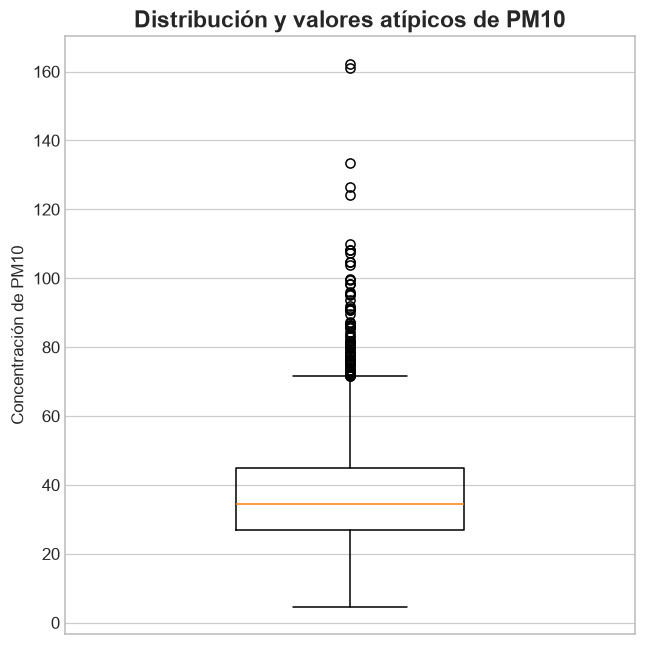

```python
fig, ax = plt.subplots(figsize=(6, 6))
ax.boxplot(pm10["Promedio"].dropna(), widths=0.4)
ax.set_title("Distribución y valores atípicos de PM10", fontweight="bold"); ax.set_ylabel("Concentración de PM10"); ax.set_xticks([])
plt.tight_layout(); plt.show()
```

### Valores atípicos de PM2.5

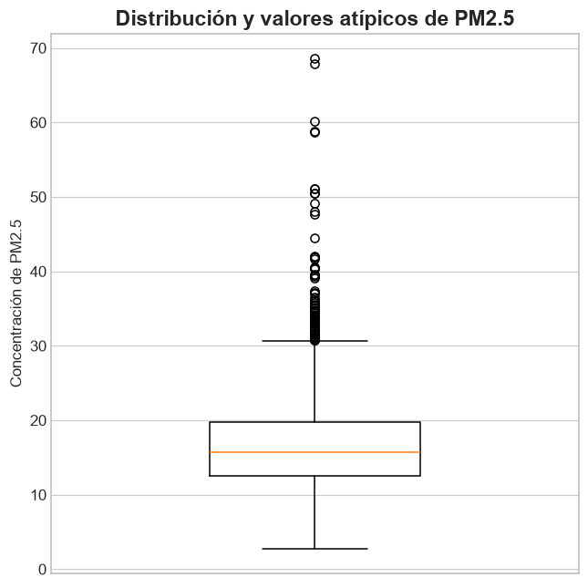

```python
fig, ax = plt.subplots(figsize=(6, 6))
ax.boxplot(pm25["Promedio"].dropna(), widths=0.4)
ax.set_title("Distribución y valores atípicos de PM2.5", fontweight="bold"); ax.set_ylabel("Concentración de PM2.5"); ax.set_xticks([])
plt.tight_layout(); plt.show()
```

### Valores atípicos de variables meteorológicas

```python
meteorologicas = df[df["Variable"].isin(["TAire", "HAire", "VViento", "P", "PLiquida", "RGlobal", "RUVb"])]
outliers_meteorologicas = meteorologicas.groupby("Variable", as_index=False).agg(Q1=("Promedio", lambda s: s.quantile(0.25)), Q3=("Promedio", lambda s: s.quantile(0.75)))
outliers_meteorologicas["IQR"] = outliers_meteorologicas["Q3"] - outliers_meteorologicas["Q1"]
outliers_meteorologicas["Limite_inferior"] = outliers_meteorologicas["Q1"] - 1.5 * outliers_meteorologicas["IQR"]
outliers_meteorologicas["Limite_superior"] = outliers_meteorologicas["Q3"] + 1.5 * outliers_meteorologicas["IQR"]
tabla(outliers_meteorologicas, ["Variable", "Primer cuartil", "Tercer cuartil", "Rango IQR", "Límite inferior", "Límite superior"])
```

| Variable | Primer cuartil | Tercer cuartil | Rango IQR | Límite inferior | Límite superior |
| --- | --- | --- | --- | --- | --- |
| HAire | 62.050000 | 76.350000 | 14.300000 | 40.600000 | 97.800000 |
| P | 629.900000 | 755.500000 | 125.600000 | 441.500000 | 943.900000 |
| PLiquida | 0.200000 | 3.400000 | 3.200000 | -4.600000 | 8.200000 |
| RGlobal | 156.880000 | 206.400000 | 49.530000 | 82.590000 | 280.690000 |
| RUVb | 1.900000 | 205.850000 | 203.950000 | -304.030000 | 511.780000 |
| TAire | 20.600000 | 25.000000 | 4.400000 | 14.000000 | 31.600000 |
| VViento | 0.900000 | 1.700000 | 0.800000 | -0.300000 | 2.900000 |

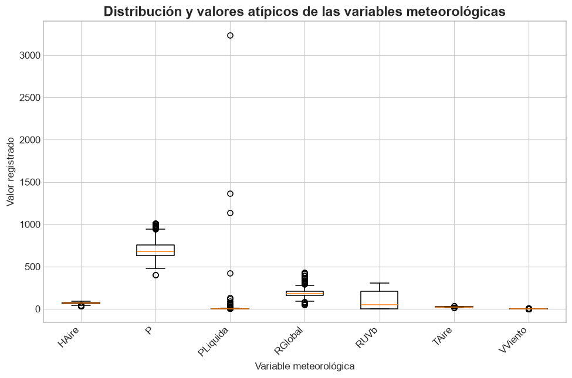

```python
orden_met = sorted(meteorologicas["Variable"].unique())
fig, ax = plt.subplots()
ax.boxplot([meteorologicas.loc[meteorologicas["Variable"] == v, "Promedio"].dropna() for v in orden_met])
ax.set_xticks(range(1, len(orden_met) + 1))
ax.set_xticklabels(orden_met)
ax.set_title("Distribución y valores atípicos de las variables meteorológicas", fontweight="bold"); ax.set_xlabel("Variable meteorológica"); ax.set_ylabel("Valor registrado")
plt.xticks(rotation=45, ha="right")
plt.tight_layout(); plt.show()
```

## 1.10 Resumen estadístico general

```python
variables_resumen = df[df["Variable"].isin(["PM10", "PM2.5", "SO2", "NO2", "O3", "TAire", "HAire", "VViento", "P", "PLiquida", "RGlobal", "RUVb"])].groupby("Variable", as_index=False).agg(N=("Promedio", "count"), Mínimo=("Promedio", "min"), Q1=("Promedio", lambda s: s.quantile(0.25)), Mediana=("Promedio", "median"), Media=("Promedio", "mean"), Q3=("Promedio", lambda s: s.quantile(0.75)), Máximo=("Promedio", "max"))
tabla(variables_resumen, ["Variable", "N", "Mínimo", "Q1", "Mediana", "Media", "Q3", "Máximo"])
```

| Variable | N | Mínimo | Q1 | Mediana | Media | Q3 | Máximo |
| --- | --- | --- | --- | --- | --- | --- | --- |
| HAire | 75 | 33.100000 | 62.050000 | 71.800000 | 66.090000 | 76.350000 | 92.000000 |
| NO2 | 644 | 0.500000 | 16.500000 | 26.000000 | 26.460000 | 35.600000 | 65.600000 |
| O3 | 827 | 2.000000 | 19.800000 | 25.700000 | 26.150000 | 31.800000 | 65.800000 |
| P | 673 | 399.100000 | 629.900000 | 677.600000 | 701.680000 | 755.500000 | 1010.400000 |
| PLiquida | 927 | 0.100000 | 0.200000 | 1.400000 | 9.770000 | 3.400000 | 3236.700000 |
| PM10 | 2984 | 4.600000 | 27.000000 | 34.600000 | 37.130000 | 44.800000 | 162.300000 |
| PM2.5 | 1984 | 2.700000 | 12.500000 | 15.700000 | 16.840000 | 19.800000 | 68.600000 |
| RGlobal | 600 | 48.300000 | 156.880000 | 178.450000 | 185.640000 | 206.400000 | 431.300000 |
| RUVb | 66 | 0.600000 | 1.900000 | 46.100000 | 112.400000 | 205.850000 | 303.800000 |
| SO2 | 1066 | 0.100000 | 3.400000 | 6.000000 | 9.430000 | 11.000000 | 91.710000 |
| TAire | 73 | 13.400000 | 20.600000 | 22.300000 | 22.620000 | 25.000000 | 33.500000 |
| VViento | 1254 | 0.100000 | 0.900000 | 1.200000 | 1.370000 | 1.700000 | 10.200000 |

# 2. Conclusiones

El análisis exploratorio de datos permitió caracterizar el comportamiento de los principales contaminantes atmosféricos y de las variables meteorológicas disponibles durante el periodo de estudio (2011-2024). Se identificaron diferencias importantes en la distribución, variabilidad y comportamiento temporal de las variables analizadas.

En cuanto al material particulado, la correlación entre PM10 y PM2.5 revela que ambas variables presentan un comportamiento temporal muy similar en los datos analizados, indicando fuentes de emisión comunes o procesos de formación relacionados.

La temperatura del aire mostró relaciones negativas importantes con varios contaminantes. A escala anual, los incrementos en la temperatura estuvieron asociados con menores valores promedio de PM10, PM2.5 y NO2. Sin embargo, las correlaciones no permiten establecer relaciones de causalidad directa.

El análisis de valores atípicos permitió identificar observaciones extremas en diferentes variables. Estos valores deben ser considerados en análisis posteriores, ya que pueden influir en medidas estadísticas como la media y en los coeficientes de correlación.

Finalmente, el análisis temporal mostró que no todas las variables cuentan con registros para todos los años del periodo de estudio, por lo que las tendencias deben interpretarse teniendo en cuenta la disponibilidad de datos. La distribución desigual de estaciones entre departamentos y municipios indica una cobertura geográfica heterogénea del monitoreo en el país.